# Case Study 2

#### Relationship Satisfaction

```r
knitr::opts_chunk$set(echo = TRUE)

ft16 <- FreqTable(emp_data$RelationshipSatisfaction )
ft16
```

```
  X Freq CumFreq      Prop   CumProp
1 1  276     276 0.1877551 0.1877551
2 2  303     579 0.2061224 0.3938776
3 3  459    1038 0.3122449 0.7061224
4 4  432    1470 0.2938776 1.0000000
```

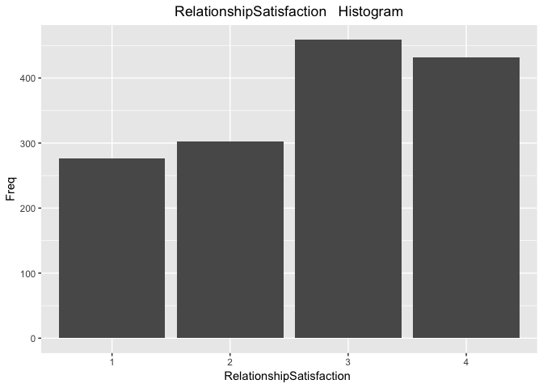

```r
ggplot(data=ft16, aes(x=X, y=Freq)) +geom_bar(stat="identity") +ylab("Freq") + xlab("RelationshipSatisfaction ") +ggtitle("RelationshipSatisfaction   Histogram")+ theme(plot.title = element_text(hjust = 0.5)) + theme(legend.position="none")
```

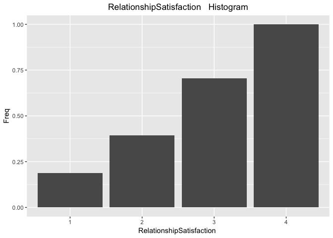

```r
ggplot(data=ft16, aes(x=X, y=CumProp)) +geom_bar(stat="identity") +ylab("Freq") + xlab("RelationshipSatisfaction ") +ggtitle("RelationshipSatisfaction   Histogram")+ theme(plot.title = element_text(hjust = 0.5)) + theme(legend.position="none")
```

```r
describe(emp_data$RelationshipSatisfaction  )
```

```
   vars    n mean   sd median trimmed  mad min max range skew kurtosis
X1    1 1470 2.71 1.08      3    2.77 1.48   1   4     3 -0.3    -1.19
     se
X1 0.03
```

```r
sum(is.na(emp_data$RelationshipSatisfaction  ))
```

```
[1] 0
```

#### Standard Hours

```r
knitr::opts_chunk$set(echo = TRUE)

ft17 <- FreqTable(emp_data$StandardHours)
ft17
```

```
   X Freq CumFreq Prop CumProp
1 80 1470    1470    1       1
```

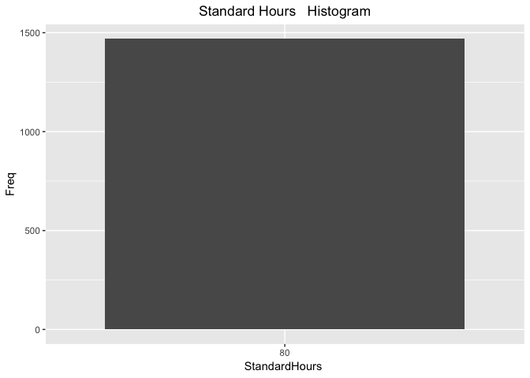

```r
ggplot(data=ft17, aes(x=X, y=Freq)) +geom_bar(stat="identity") +ylab("Freq") + xlab("StandardHours ") +ggtitle("Standard Hours   Histogram")+ theme(plot.title = element_text(hjust = 0.5)) + theme(legend.position="none")
```

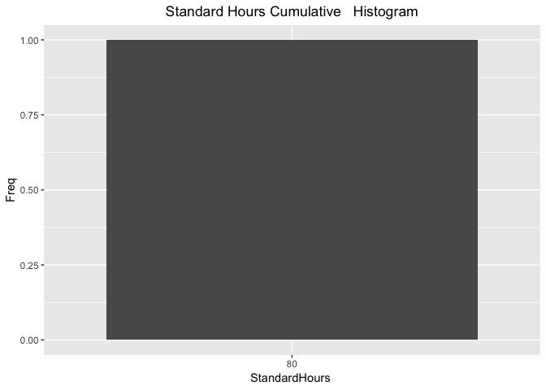

```r
ggplot(data=ft17, aes(x=X, y=CumProp)) +geom_bar(stat="identity") +ylab("Freq") + xlab("StandardHours ") +ggtitle("Standard Hours Cumulative   Histogram")+ theme(plot.title = element_text(hjust = 0.5)) + theme(legend.position="none")
```

```r
describe(emp_data$StandardHours)
```

```
   vars    n mean sd median trimmed mad min max range skew kurtosis se
X1    1 1470   80  0     80      80   0  80  80     0  NaN      NaN  0
```

```r
sum(is.na(emp_data$StandardHours))
```

```
[1] 0
```

```r
### note standard hours has no variance drop this variable
```

### Stock Option Level

```r
knitr::opts_chunk$set(echo = TRUE)

ft18 <- FreqTable(emp_data$StockOptionLevel)
ft18
```

```
  X Freq CumFreq       Prop   CumProp
1 0  631     631 0.42925170 0.4292517
2 1  596    1227 0.40544218 0.8346939
3 2  158    1385 0.10748299 0.9421769
4 3   85    1470 0.05782313 1.0000000
```

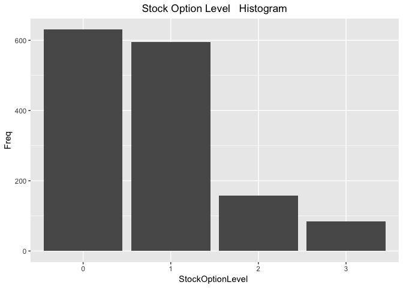

```r
ggplot(data=ft18, aes(x=X, y=Freq)) +geom_bar(stat="identity") +ylab("Freq") + xlab("StockOptionLevel ") +ggtitle("Stock Option Level   Histogram")+ theme(plot.title = element_text(hjust = 0.5)) + theme(legend.position="none")
```

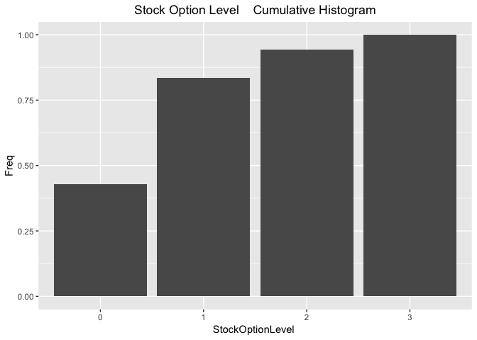

```r
ggplot(data=ft18, aes(x=X, y=CumProp)) +geom_bar(stat="identity") +ylab("Freq") + xlab("StockOptionLevel ") +ggtitle("Stock Option Level    Cumulative Histogram")+ theme(plot.title = element_text(hjust = 0.5)) + theme(legend.position="none")
```

```r
describe(emp_data$StockOptionLevel)
```

```
   vars    n mean   sd median trimmed  mad min max range skew kurtosis
X1    1 1470 0.79 0.85      1    0.67 1.48   0   3     3 0.97     0.35
     se
X1 0.02
```

```r
sum(is.na(emp_data$StockOptionLevel))
```

```
[1] 0
```

#### Total Working Years

```r
knitr::opts_chunk$set(echo = TRUE)

ft19 <- FreqTable(emp_data$TotalWorkingYears)
ft19
```

```
    X Freq CumFreq         Prop     CumProp
1   0   11      11 0.0074829932 0.007482993
2   1   81      92 0.0551020408 0.062585034
3   2   31     123 0.0210884354 0.083673469
4   3   42     165 0.0285714286 0.112244898
5   4   63     228 0.0428571429 0.155102041
6   5   88     316 0.0598639456 0.214965986
7   6  125     441 0.0850340136 0.300000000
8   7   81     522 0.0551020408 0.355102041
9   8  103     625 0.0700680272 0.425170068
10  9   96     721 0.0653061224 0.490476190
11 10  202     923 0.1374149660 0.627891156
12 11   36     959 0.0244897959 0.652380952
13 12   48    1007 0.0326530612 0.685034014
14 13   36    1043 0.0244897959 0.709523810
```

[output cut: 26 more lines]

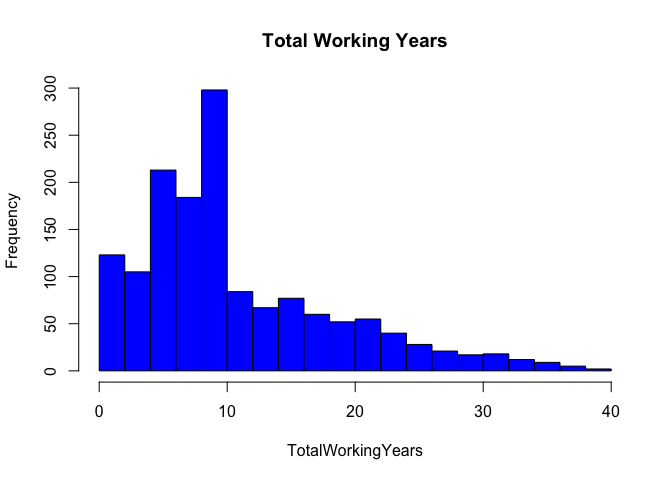

```r
hist(emp_data$TotalWorkingYears, main="Total Working Years", breaks=15, xlab="TotalWorkingYears", border="black", col="blue", xlim=c(0,40))
```

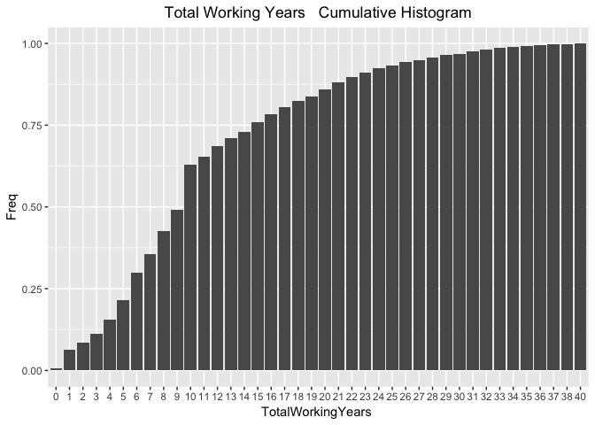

```r
ggplot(data=ft19, aes(x=X, y=CumProp)) +geom_bar(stat="identity") +ylab("Freq") + xlab("TotalWorkingYears ") +ggtitle("Total Working Years   Cumulative Histogram")+ theme(plot.title = element_text(hjust = 0.5)) + theme(legend.position="none")
```

```r
describe(emp_data$TotalWorkingYears)
```

```
   vars    n  mean   sd median trimmed  mad min max range skew kurtosis
X1    1 1470 11.28 7.78     10   10.37 5.93   0  40    40 1.11     0.91
    se
X1 0.2
```

```r
sum(is.na(emp_data$TotalWorkingYears))
```

```
[1] 0
```

#### Training Times last year

```r
knitr::opts_chunk$set(echo = TRUE)

ft20 <- FreqTable(emp_data$TrainingTimesLastYear)
ft20
```

```
  X Freq CumFreq       Prop    CumProp
1 0   54      54 0.03673469 0.03673469
2 1   71     125 0.04829932 0.08503401
3 2  547     672 0.37210884 0.45714286
4 3  491    1163 0.33401361 0.79115646
5 4  123    1286 0.08367347 0.87482993
6 5  119    1405 0.08095238 0.95578231
7 6   65    1470 0.04421769 1.00000000
```

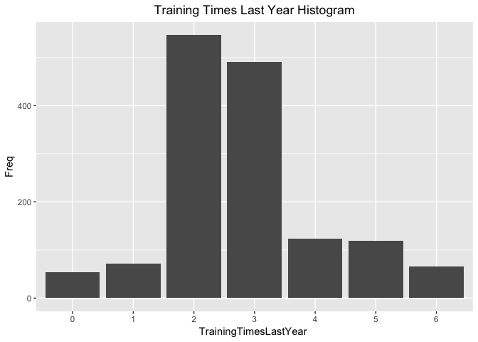

```r
ggplot(data=ft20, aes(x=X, y=Freq)) +geom_bar(stat="identity") +ylab("Freq") + xlab("TrainingTimesLastYear ") +ggtitle("Training Times Last Year Histogram")+ theme(plot.title = element_text(hjust = 0.5)) + theme(legend.position="none")
```

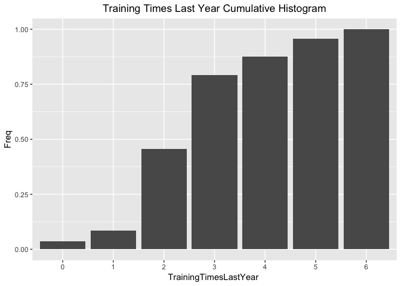

```r
ggplot(data=ft20, aes(x=X, y=CumProp)) +geom_bar(stat="identity") +ylab("Freq") + xlab("TrainingTimesLastYear ") +ggtitle("Training Times Last Year Cumulative Histogram")+ theme(plot.title = element_text(hjust = 0.5)) + theme(legend.position="none")
```

```r
describe(emp_data$TrainingTimesLastYear)
```

```
   vars    n mean   sd median trimmed  mad min max range skew kurtosis
X1    1 1470  2.8 1.29      3    2.72 1.48   0   6     6 0.55     0.48
     se
X1 0.03
```

```r
sum(is.na(emp_data$TrainingTimesLastYear))
```

```
[1] 0
```

#### Work Life Balance

```r
knitr::opts_chunk$set(echo = TRUE)

ft21 <- FreqTable(emp_data$WorkLifeBalance)
ft21
```

```
  X Freq CumFreq       Prop    CumProp
1 1   80      80 0.05442177 0.05442177
2 2  344     424 0.23401361 0.28843537
3 3  893    1317 0.60748299 0.89591837
4 4  153    1470 0.10408163 1.00000000
```

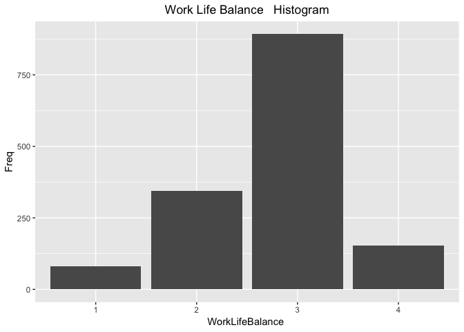

```r
ggplot(data=ft21, aes(x=X, y=Freq)) +geom_bar(stat="identity") +ylab("Freq") + xlab("WorkLifeBalance ") +ggtitle("Work Life Balance   Histogram")+ theme(plot.title = element_text(hjust = 0.5)) + theme(legend.position="none")
```

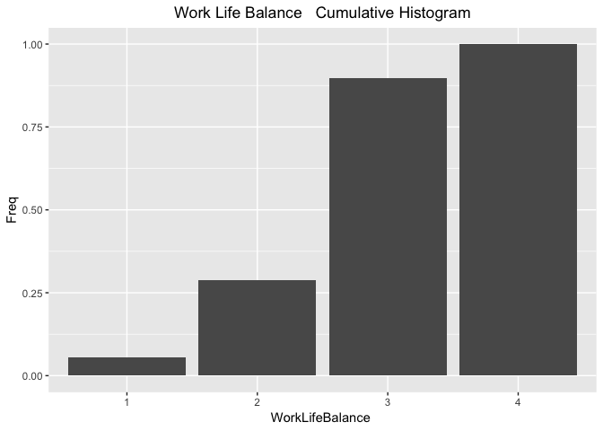

```r
ggplot(data=ft21, aes(x=X, y=CumProp)) +geom_bar(stat="identity") +ylab("Freq") + xlab("WorkLifeBalance ") +ggtitle("Work Life Balance   Cumulative Histogram")+ theme(plot.title = element_text(hjust = 0.5)) + theme(legend.position="none")
```

```r
describe(emp_data$WorkLifeBalance)
```

```
   vars    n mean   sd median trimmed mad min max range  skew kurtosis
X1    1 1470 2.76 0.71      3    2.77   0   1   4     3 -0.55     0.41
     se
X1 0.02
```

```r
sum(is.na(emp_data$WorkLifeBalance))
```

```
[1] 0
```

### Years at Company

```r
knitr::opts_chunk$set(echo = TRUE)

ft22 <- FreqTable(emp_data$YearsAtCompany)
ft22
```

```
    X Freq CumFreq         Prop    CumProp
1   0   44      44 0.0299319728 0.02993197
2   1  171     215 0.1163265306 0.14625850
3   2  127     342 0.0863945578 0.23265306
4   3  128     470 0.0870748299 0.31972789
5   4  110     580 0.0748299320 0.39455782
6   5  196     776 0.1333333333 0.52789116
7   6   76     852 0.0517006803 0.57959184
8   7   90     942 0.0612244898 0.64081633
9   8   80    1022 0.0544217687 0.69523810
10  9   82    1104 0.0557823129 0.75102041
11 10  120    1224 0.0816326531 0.83265306
12 11   32    1256 0.0217687075 0.85442177
13 12   14    1270 0.0095238095 0.86394558
14 13   24    1294 0.0163265306 0.88027211
```

[output cut: 23 more lines]

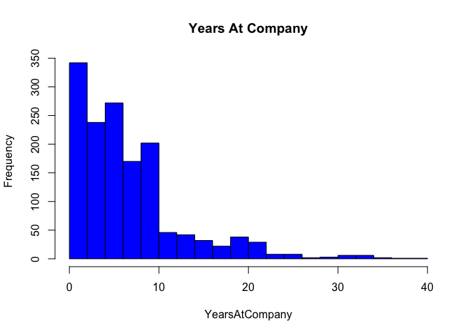

```r
hist(emp_data$YearsAtCompany, main="Years At Company", breaks=15, xlab="YearsAtCompany", border="black", col="blue", xlim=c(0,40))
```

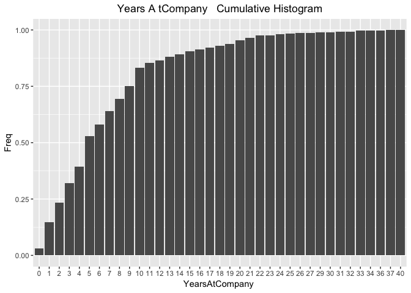

```r
ggplot(data=ft22, aes(x=X, y=CumProp)) +geom_bar(stat="identity") +ylab("Freq") + xlab("YearsAtCompany ") +ggtitle("Years A tCompany   Cumulative Histogram")+ theme(plot.title = element_text(hjust = 0.5)) + theme(legend.position="none")
```

```r
describe(emp_data$YearsAtCompany)
```

```
   vars    n mean   sd median trimmed  mad min max range skew kurtosis
X1    1 1470 7.01 6.13      5    5.99 4.45   0  40    40 1.76     3.91
     se
X1 0.16
```

```r
sum(is.na(emp_data$YearsAtCompany))
```

```
[1] 0
```

#### Years in Current Role

```r
knitr::opts_chunk$set(echo = TRUE)

ft23 <- FreqTable(emp_data$YearsInCurrentRole)
ft23
```

```
    X Freq CumFreq        Prop   CumProp
1   0  244     244 0.165986395 0.1659864
2   1   57     301 0.038775510 0.2047619
3   2  372     673 0.253061224 0.4578231
4   3  135     808 0.091836735 0.5496599
5   4  104     912 0.070748299 0.6204082
6   5   36     948 0.024489796 0.6448980
7   6   37     985 0.025170068 0.6700680
8   7  222    1207 0.151020408 0.8210884
9   8   89    1296 0.060544218 0.8816327
10  9   67    1363 0.045578231 0.9272109
11 10   29    1392 0.019727891 0.9469388
12 11   22    1414 0.014965986 0.9619048
13 12   10    1424 0.006802721 0.9687075
14 13   14    1438 0.009523810 0.9782313
15 14   11    1449 0.007482993 0.9857143
16 15    8    1457 0.005442177 0.9911565
17 16    7    1464 0.004761905 0.9959184
18 17    4    1468 0.002721088 0.9986395
19 18    2    1470 0.001360544 1.0000000
```

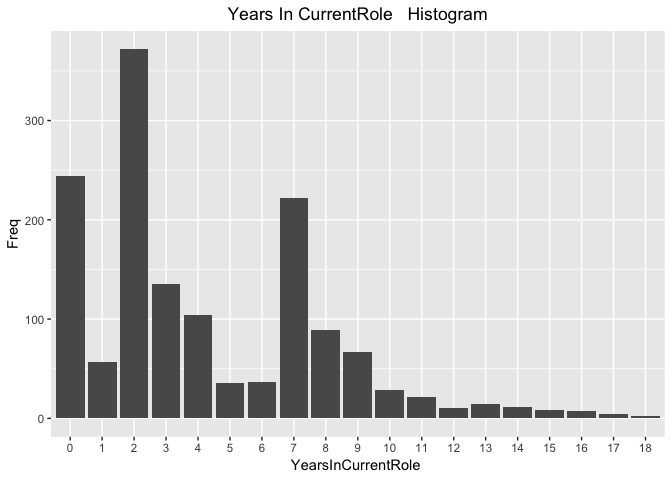

```r
ggplot(data=ft23, aes(x=X, y=Freq)) +geom_bar(stat="identity") +ylab("Freq") + xlab("YearsInCurrentRole ") +ggtitle("Years In CurrentRole   Histogram")+ theme(plot.title = element_text(hjust = 0.5)) + theme(legend.position="none")
```

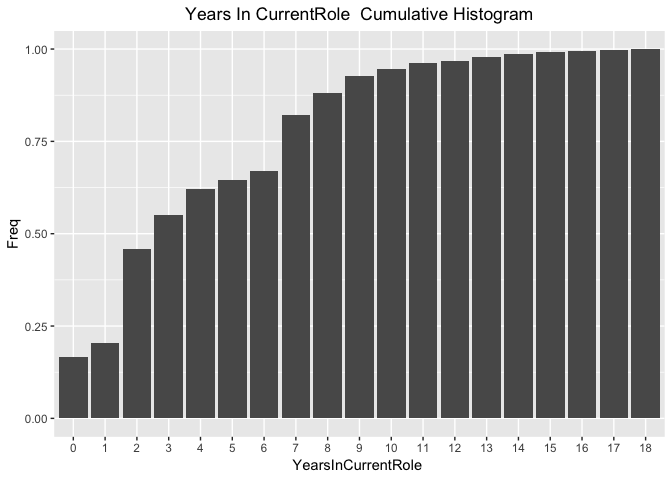

```r
ggplot(data=ft23, aes(x=X, y=CumProp)) +geom_bar(stat="identity") +ylab("Freq") + xlab("YearsInCurrentRole ") +ggtitle("Years In CurrentRole  Cumulative Histogram")+ theme(plot.title = element_text(hjust = 0.5)) + theme(legend.position="none")
```

```r
describe(emp_data$YearsInCurrentRole)
```

```
   vars    n mean   sd median trimmed  mad min max range skew kurtosis
X1    1 1470 4.23 3.62      3    3.85 4.45   0  18    18 0.92     0.47
     se
X1 0.09
```

```r
sum(is.na(emp_data$YearsInCurrentRole))
```

```
[1] 0
```

#### Years Since Last Promotion

```r
knitr::opts_chunk$set(echo = TRUE)

ft24 <- FreqTable(emp_data$YearsSinceLastPromotion)
ft24
```

```
    X Freq CumFreq        Prop   CumProp
1   0  581     581 0.395238095 0.3952381
2   1  357     938 0.242857143 0.6380952
3   2  159    1097 0.108163265 0.7462585
4   3   52    1149 0.035374150 0.7816327
5   4   61    1210 0.041496599 0.8231293
6   5   45    1255 0.030612245 0.8537415
7   6   32    1287 0.021768707 0.8755102
8   7   76    1363 0.051700680 0.9272109
9   8   18    1381 0.012244898 0.9394558
10  9   17    1398 0.011564626 0.9510204
11 10    6    1404 0.004081633 0.9551020
12 11   24    1428 0.016326531 0.9714286
13 12   10    1438 0.006802721 0.9782313
14 13   10    1448 0.006802721 0.9850340
15 14    9    1457 0.006122449 0.9911565
16 15   13    1470 0.008843537 1.0000000
```

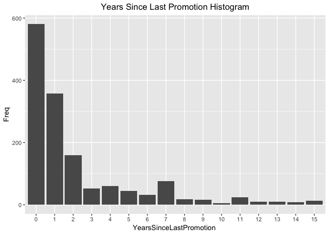

```r
ggplot(data=ft24, aes(x=X, y=Freq)) +geom_bar(stat="identity") +ylab("Freq") + xlab("YearsSinceLastPromotion ") +ggtitle("Years Since Last Promotion Histogram")+ theme(plot.title = element_text(hjust = 0.5)) + theme(legend.position="none")
```

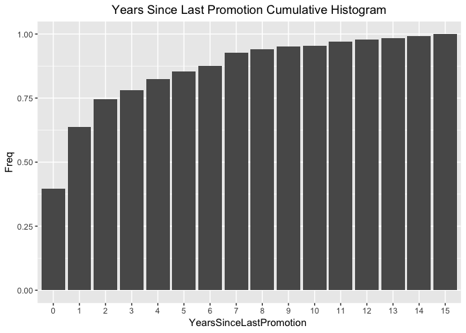

```r
ggplot(data=ft24, aes(x=X, y=CumProp)) +geom_bar(stat="identity") +ylab("Freq") + xlab("YearsSinceLastPromotion ") +ggtitle("Years Since Last Promotion Cumulative Histogram")+ theme(plot.title = element_text(hjust = 0.5)) + theme(legend.position="none")
```

```r
describe(emp_data$YearsSinceLastPromotion)
```

```
   vars    n mean   sd median trimmed  mad min max range skew kurtosis
X1    1 1470 2.19 3.22      1    1.48 1.48   0  15    15 1.98     3.59
     se
X1 0.08
```

```r
sum(is.na(emp_data$YearsSinceLastPromotion))
```

```
[1] 0
```

#### Years with Current Manager

```r
knitr::opts_chunk$set(echo = TRUE)

ft25 <- FreqTable(emp_data$YearsWithCurrManager)
ft25
```

```
    X Freq CumFreq        Prop   CumProp
1   0  263     263 0.178911565 0.1789116
2   1   76     339 0.051700680 0.2306122
3   2  344     683 0.234013605 0.4646259
4   3  142     825 0.096598639 0.5612245
5   4   98     923 0.066666667 0.6278912
6   5   31     954 0.021088435 0.6489796
7   6   29     983 0.019727891 0.6687075
8   7  216    1199 0.146938776 0.8156463
9   8  107    1306 0.072789116 0.8884354
10  9   64    1370 0.043537415 0.9319728
11 10   27    1397 0.018367347 0.9503401
12 11   22    1419 0.014965986 0.9653061
13 12   18    1437 0.012244898 0.9775510
14 13   14    1451 0.009523810 0.9870748
15 14    5    1456 0.003401361 0.9904762
16 15    5    1461 0.003401361 0.9938776
17 16    2    1463 0.001360544 0.9952381
18 17    7    1470 0.004761905 1.0000000
```

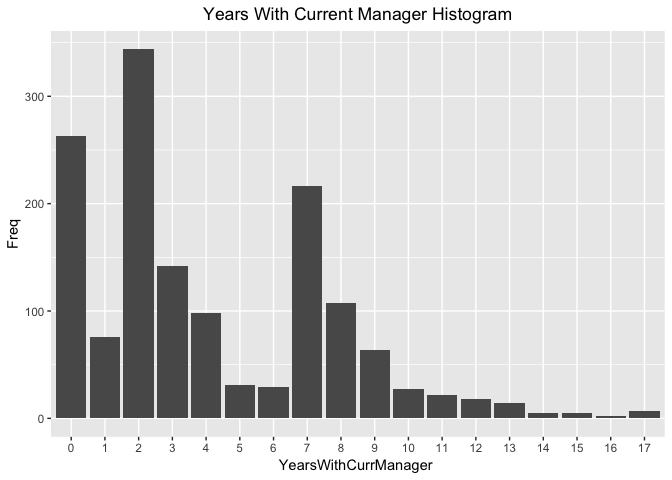

```r
ggplot(data=ft25, aes(x=X, y=Freq)) +geom_bar(stat="identity") +ylab("Freq") + xlab("YearsWithCurrManager ") +ggtitle("Years With Current Manager Histogram")+ theme(plot.title = element_text(hjust = 0.5)) + theme(legend.position="none")
```

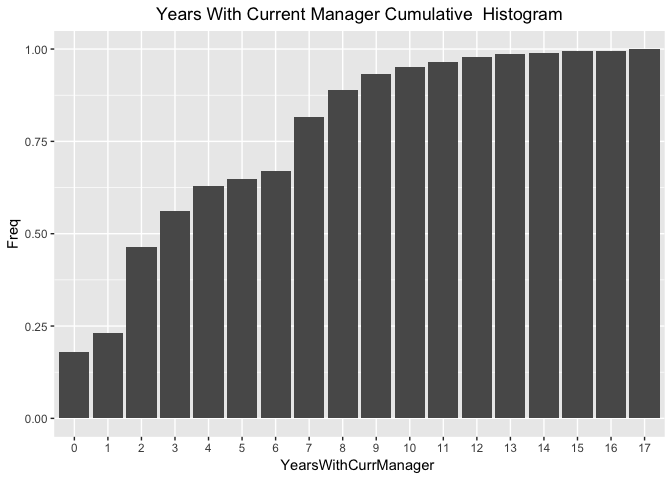

```r
ggplot(data=ft25, aes(x=X, y=CumProp)) +geom_bar(stat="identity") +ylab("Freq") + xlab("YearsWithCurrManager ") +ggtitle("Years With Current Manager Cumulative  Histogram")+ theme(plot.title = element_text(hjust = 0.5)) + theme(legend.position="none")
```

```r
describe(emp_data$YearsWithCurrManager)
```

```
   vars    n mean   sd median trimmed  mad min max range skew kurtosis
X1    1 1470 4.12 3.57      3    3.77 4.45   0  17    17 0.83     0.16
     se
X1 0.09
```

```r
sum(is.na(emp_data$YearsWithCurrManager))
```

```
[1] 0
```

##### Observations on Continuous Variables

Most variables are no normally distributed, show significant skew and/or kurtosis Some variables have no information and wil be dropped 1. Standard Hours 2. Employee Count

Performance Rating has very little variance with only 3’s and a few 4 ratings—This variable may not be useful

No missing data was observed for any variable

##### Next Step - Review Distributions of Nominal Variables

```r
knitr::opts_chunk$set(echo = TRUE)

FreqTable(emp_data$Attrition)
```

```
    X Freq CumFreq      Prop   CumProp
1  No 1233    1233 0.8387755 0.8387755
2 Yes  237    1470 0.1612245 1.0000000
```

```r
FreqTable(emp_data$BusinessTravel)
```

```
                  X Freq CumFreq      Prop   CumProp
1        Non-Travel  150     150 0.1020408 0.1020408
2 Travel_Frequently  277     427 0.1884354 0.2904762
3     Travel_Rarely 1043    1470 0.7095238 1.0000000
```

```r
FreqTable(emp_data$Department)
```

```
                       X Freq CumFreq       Prop    CumProp
1        Human Resources   63      63 0.04285714 0.04285714
2 Research & Development  961    1024 0.65374150 0.69659864
3                  Sales  446    1470 0.30340136 1.00000000
```

```r
FreqTable(emp_data$EducationField)
```

```
                 X Freq CumFreq       Prop    CumProp
1  Human Resources   27      27 0.01836735 0.01836735
2    Life Sciences  606     633 0.41224490 0.43061224
3        Marketing  159     792 0.10816327 0.53877551
4          Medical  464    1256 0.31564626 0.85442177
5            Other   82    1338 0.05578231 0.91020408
6 Technical Degree  132    1470 0.08979592 1.00000000
```

```r
FreqTable(emp_data$Gender)
```

```
       X Freq CumFreq Prop CumProp
1 Female  588     588  0.4     0.4
2   Male  882    1470  0.6     1.0
```

```r
FreqTable(emp_data$JobRole)
```

```
                          X Freq CumFreq       Prop    CumProp
1 Healthcare Representative  131     131 0.08911565 0.08911565
2           Human Resources   52     183 0.03537415 0.12448980
3     Laboratory Technician  259     442 0.17619048 0.30068027
4                   Manager  102     544 0.06938776 0.37006803
5    Manufacturing Director  145     689 0.09863946 0.46870748
6         Research Director   80     769 0.05442177 0.52312925
7        Research Scientist  292    1061 0.19863946 0.72176871
8           Sales Executive  326    1387 0.22176871 0.94353741
9      Sales Representative   83    1470 0.05646259 1.00000000
```

```r
FreqTable(emp_data$MaritalStatus)
```

```
         X Freq CumFreq      Prop   CumProp
1 Divorced  327     327 0.2224490 0.2224490
2  Married  673    1000 0.4578231 0.6802721
3   Single  470    1470 0.3197279 1.0000000
```

```r
FreqTable(emp_data$Over18)
```

```
  X Freq CumFreq Prop CumProp
1 Y 1470    1470    1       1
```

```r
FreqTable(emp_data$OverTime)
```

```
    X Freq CumFreq      Prop   CumProp
1  No 1054    1054 0.7170068 0.7170068
2 Yes  416    1470 0.2829932 1.0000000
```

#### Observations from nominal variables

No variable have missing data

##### Next step is to identify which continuous variables are associated with attrition

For this exploratory activity, we will use a t-test without adjustment for number of tests as we do not want to eliminate variables that may be additive in a more comprehensive model

```r
knitr::opts_chunk$set(echo = TRUE)

t.test(emp_data$Age~emp_data$Attrition)
```

```
    Welch Two Sample t-test

data:  emp_data$Age by emp_data$Attrition
t = 5.828, df = 316.93, p-value = 1.38e-08
alternative hypothesis: true difference in means is not equal to 0
95 percent confidence interval:
 2.618930 5.288346
sample estimates:
 mean in group No mean in group Yes
         37.56123          33.60759
```

```r
t.test(emp_data$DailyRate~emp_data$Attrition)
```

```
    Welch Two Sample t-test

data:  emp_data$DailyRate by emp_data$Attrition
t = 2.1789, df = 333.76, p-value = 0.03004
alternative hypothesis: true difference in means is not equal to 0
95 percent confidence interval:
   6.040083 118.243100
sample estimates:
 mean in group No mean in group Yes
         812.5045          750.3629
```

```r
t.test(emp_data$DistanceFromHome~emp_data$Attrition)
```

```
    Welch Two Sample t-test

data:  emp_data$DistanceFromHome by emp_data$Attrition
t = -2.8882, df = 322.72, p-value = 0.004137
alternative hypothesis: true difference in means is not equal to 0
95 percent confidence interval:
 -2.8870025 -0.5475146
sample estimates:
 mean in group No mean in group Yes
         8.915653         10.632911
```

```r
t.test( emp_data$Education~emp_data$Attrition)
```

```
    Welch Two Sample t-test

data:  emp_data$Education by emp_data$Attrition
t = 1.2177, df = 336.95, p-value = 0.2242
alternative hypothesis: true difference in means is not equal to 0
95 percent confidence interval:
 -0.05374319  0.22843290
sample estimates:
 mean in group No mean in group Yes
         2.927007          2.839662
```

```r
t.test( emp_data$EnvironmentSatisfaction~emp_data$Attrition)
```

```
    Welch Two Sample t-test

data:  emp_data$EnvironmentSatisfaction by emp_data$Attrition
t = 3.7513, df = 316.62, p-value = 0.0002092
alternative hypothesis: true difference in means is not equal to 0
95 percent confidence interval:
 0.146056 0.468253
sample estimates:
 mean in group No mean in group Yes
         2.771290          2.464135
```

```r
t.test( emp_data$HourlyRate~emp_data$Attrition)
```

```
    Welch Two Sample t-test

data:  emp_data$HourlyRate by emp_data$Attrition
t = 0.26477, df = 335.98, p-value = 0.7914
alternative hypothesis: true difference in means is not equal to 0
95 percent confidence interval:
 -2.432272  3.188891
sample estimates:
 mean in group No mean in group Yes
         65.95215          65.57384
```

```r
t.test( emp_data$JobInvolvement~emp_data$Attrition)
```

```
    Welch Two Sample t-test

data:  emp_data$JobInvolvement by emp_data$Attrition
t = 4.6602, df = 312.81, p-value = 4.681e-06
alternative hypothesis: true difference in means is not equal to 0
95 percent confidence interval:
 0.1453097 0.3576727
sample estimates:
 mean in group No mean in group Yes
         2.770479          2.518987
```

```r
t.test( emp_data$JobLevel~emp_data$Attrition)
```

```
    Welch Two Sample t-test

data:  emp_data$JobLevel by emp_data$Attrition
t = 7.3859, df = 376.25, p-value = 9.845e-13
alternative hypothesis: true difference in means is not equal to 0
95 percent confidence interval:
 0.3733861 0.6443231
sample estimates:
 mean in group No mean in group Yes
         2.145985          1.637131
```

```r
t.test( emp_data$JobSatisfaction~emp_data$Attrition)
```

```
    Welch Two Sample t-test

data:  emp_data$JobSatisfaction by emp_data$Attrition
t = 3.9261, df = 328.59, p-value = 0.0001052
alternative hypothesis: true difference in means is not equal to 0
95 percent confidence interval:
 0.1547890 0.4656797
sample estimates:
 mean in group No mean in group Yes
         2.778589          2.468354
```

```r
t.test( emp_data$MonthlyIncome~emp_data$Attrition)
```

```
    Welch Two Sample t-test

data:  emp_data$MonthlyIncome by emp_data$Attrition
t = 7.4826, df = 412.74, p-value = 4.434e-13
alternative hypothesis: true difference in means is not equal to 0
95 percent confidence interval:
 1508.244 2583.050
sample estimates:
 mean in group No mean in group Yes
         6832.740          4787.093
```

```r
t.test( emp_data$MonthlyRate~emp_data$Attrition)
```

```
    Welch Two Sample t-test

data:  emp_data$MonthlyRate by emp_data$Attrition
t = -0.5755, df = 330.1, p-value = 0.5653
alternative hypothesis: true difference in means is not equal to 0
95 percent confidence interval:
 -1296.8656   709.8084
sample estimates:
 mean in group No mean in group Yes
         14265.78          14559.31
```

```r
t.test( emp_data$NumCompaniesWorked~emp_data$Attrition)
```

```
    Welch Two Sample t-test

data:  emp_data$NumCompaniesWorked by emp_data$Attrition
t = -1.5747, df = 317.14, p-value = 0.1163
alternative hypothesis: true difference in means is not equal to 0
95 percent confidence interval:
 -0.66437603  0.07367926
sample estimates:
 mean in group No mean in group Yes
         2.645580          2.940928
```

```r
t.test( emp_data$PercentSalaryHike~emp_data$Attrition)
```

```
    Welch Two Sample t-test

data:  emp_data$PercentSalaryHike by emp_data$Attrition
t = 0.50424, df = 326.11, p-value = 0.6144
alternative hypothesis: true difference in means is not equal to 0
95 percent confidence interval:
 -0.3890709  0.6572652
sample estimates:
 mean in group No mean in group Yes
         15.23114          15.09705
```

```r
t.test( emp_data$PerformanceRating~emp_data$Attrition)
```

```
    Welch Two Sample t-test

data:  emp_data$PerformanceRating by emp_data$Attrition
t = -0.10999, df = 331.22, p-value = 0.9125
alternative hypothesis: true difference in means is not equal to 0
95 percent confidence interval:
 -0.05350780  0.04784086
sample estimates:
 mean in group No mean in group Yes
         3.153285          3.156118
```

```r
t.test( emp_data$RelationshipSatisfaction~emp_data$Attrition)
```

```
    Welch Two Sample t-test

data:  emp_data$RelationshipSatisfaction by emp_data$Attrition
t = 1.7019, df = 323.54, p-value = 0.08973
alternative hypothesis: true difference in means is not equal to 0
95 percent confidence interval:
 -0.02102367  0.29067575
sample estimates:
 mean in group No mean in group Yes
         2.733982          2.599156
```

```r
t.test( emp_data$StockOptionLevel~emp_data$Attrition)
```

```
    Welch Two Sample t-test

data:  emp_data$StockOptionLevel by emp_data$Attrition
t = 5.2442, df = 329.67, p-value = 2.812e-07
alternative hypothesis: true difference in means is not equal to 0
95 percent confidence interval:
 0.1985054 0.4368288
sample estimates:
 mean in group No mean in group Yes
        0.8450933         0.5274262
```

```r
t.test( emp_data$TotalWorkingYears~emp_data$Attrition)
```

```
    Welch Two Sample t-test

data:  emp_data$TotalWorkingYears by emp_data$Attrition
t = 7.0192, df = 350.88, p-value = 1.16e-11
alternative hypothesis: true difference in means is not equal to 0
95 percent confidence interval:
 2.604401 4.632019
sample estimates:
 mean in group No mean in group Yes
        11.862936          8.244726
```

```r
t.test( emp_data$TrainingTimesLastYear~emp_data$Attrition)
```

```
    Welch Two Sample t-test

data:  emp_data$TrainingTimesLastYear by emp_data$Attrition
t = 2.3305, df = 339.56, p-value = 0.02036
alternative hypothesis: true difference in means is not equal to 0
95 percent confidence interval:
 0.03251776 0.38439273
sample estimates:
 mean in group No mean in group Yes
         2.832928          2.624473
```

```r
t.test( emp_data$WorkLifeBalance~emp_data$Attrition)
```

```
    Welch Two Sample t-test

data:  emp_data$WorkLifeBalance by emp_data$Attrition
t = 2.1742, df = 302.49, p-value = 0.03047
alternative hypothesis: true difference in means is not equal to 0
95 percent confidence interval:
 0.01165453 0.23393357
sample estimates:
 mean in group No mean in group Yes
         2.781022          2.658228
```

```r
t.test( emp_data$YearsAtCompany~emp_data$Attrition)
```

```
    Welch Two Sample t-test

data:  emp_data$YearsAtCompany by emp_data$Attrition
t = 5.2826, df = 338.21, p-value = 2.286e-07
alternative hypothesis: true difference in means is not equal to 0
95 percent confidence interval:
 1.404805 3.071629
sample estimates:
 mean in group No mean in group Yes
         7.369019          5.130802
```

```r
t.test( emp_data$YearsInCurrentRole~emp_data$Attrition)
```

```
    Welch Two Sample t-test

data:  emp_data$YearsInCurrentRole by emp_data$Attrition
t = 6.8471, df = 366.57, p-value = 3.187e-11
alternative hypothesis: true difference in means is not equal to 0
95 percent confidence interval:
 1.127107 2.035355
sample estimates:
 mean in group No mean in group Yes
         4.484185          2.902954
```

```r
t.test( emp_data$YearsSinceLastPromotion~emp_data$Attrition)
```

```
    Welch Two Sample t-test

data:  emp_data$YearsSinceLastPromotion by emp_data$Attrition
t = 1.2879, df = 338.49, p-value = 0.1987
alternative hypothesis: true difference in means is not equal to 0
95 percent confidence interval:
 -0.1525043  0.7309843
sample estimates:
 mean in group No mean in group Yes
         2.234388          1.945148
```

```r
t.test( emp_data$YearsWithCurrManager~emp_data$Attrition)
```

```
    Welch Two Sample t-test

data:  emp_data$YearsWithCurrManager by emp_data$Attrition
t = 6.6334, df = 365.1, p-value = 1.185e-10
alternative hypothesis: true difference in means is not equal to 0
95 percent confidence interval:
 1.065929 1.964223
sample estimates:
 mean in group No mean in group Yes
         4.367397          2.852321
```

#### Findings from exploratory t-tests of ordinal Continuous Variables

Variables that are significant related to attrition Age (p < .0001), Daily Rate (p < .05), Distance from Home (p < .01), Satisfaction with Work Environment (p < .001), Job Involvement (p < .0001), Job Level (p < .0001), Job Satisfaction (p < .001), Monthly Income (p < .0001), Relationship Satisfaction (p < .10 – borderline result), Stock Option Level ( p < .0001), Total Working Years ( p < .0001), Training Times Last Year (p < .05), Work Life Balance ( p < .05), Years at Company (p < .0001), Years in Current Role ( p < .0001), Years with Current Manager (P < .0001)

There are many potential predictors of attrition

#### Next step use chi-square to identify nominal variables that may be associated with attrition

```r
knitr::opts_chunk$set(echo = TRUE)

ct1 <- table(emp_data$RelationshipSatisfaction,emp_data$Attrition)
ct2 <- table(emp_data$BusinessTravel,emp_data$Attrition)
ct3 <- table(emp_data$Department,emp_data$Attrition)
ct4 <- table(emp_data$EducationField,emp_data$Attrition)
ct5 <- table(emp_data$Gender,emp_data$Attrition)
ct6 <- table(emp_data$JobRole,emp_data$Attrition)
ct7 <- table(emp_data$MaritalStatus,emp_data$Attrition)
ct9 <- table(emp_data$OverTime,emp_data$Attrition)
ct10 <- table(emp_data$JobSatisfaction,emp_data$Attrition)
ct11 <- table(emp_data$EnvironmentSatisfaction,emp_data$Attrition)
ct12 <- table(emp_data$Education,emp_data$Attrition)
chisq.test(ct1)
```

```
    Pearson's Chi-squared test

data:  ct1
X-squared = 5.2411, df = 3, p-value = 0.155
```

```r
chisq.test(ct2)
```

```
    Pearson's Chi-squared test

data:  ct2
X-squared = 24.182, df = 2, p-value = 5.609e-06
```

```r
chisq.test(ct3)
```

```
    Pearson's Chi-squared test

data:  ct3
X-squared = 10.796, df = 2, p-value = 0.004526
```

```r
chisq.test(ct4)
```

```
    Pearson's Chi-squared test

data:  ct4
X-squared = 16.025, df = 5, p-value = 0.006774
```

```r
chisq.test(ct5)
```

```
    Pearson's Chi-squared test with Yates' continuity correction

data:  ct5
X-squared = 1.117, df = 1, p-value = 0.2906
```

```r
chisq.test(ct6)
```

```
    Pearson's Chi-squared test

data:  ct6
X-squared = 86.19, df = 8, p-value = 2.752e-15
```

```r
chisq.test(ct7)
```

```
    Pearson's Chi-squared test

data:  ct7
X-squared = 46.164, df = 2, p-value = 9.456e-11
```

```r
chisq.test(ct9)
```

```
    Pearson's Chi-squared test with Yates' continuity correction

data:  ct9
X-squared = 87.564, df = 1, p-value < 2.2e-16
```

```r
chisq.test(ct10)
```

```
    Pearson's Chi-squared test

data:  ct10
X-squared = 17.505, df = 3, p-value = 0.0005563
```

```r
chisq.test(ct11)
```

```
    Pearson's Chi-squared test

data:  ct11
X-squared = 22.504, df = 3, p-value = 5.123e-05
```

```r
chisq.test(ct12)
```

```
    Pearson's Chi-squared test

data:  ct12
X-squared = 3.074, df = 4, p-value = 0.5455
```

```r
ct2
```

```
                     No Yes
  Non-Travel        138  12
  Travel_Frequently 208  69
  Travel_Rarely     887 156
```

```r
ct3
```

```
                          No Yes
  Human Resources         51  12
  Research & Development 828 133
  Sales                  354  92
```

```r
ct4
```

```
                    No Yes
  Human Resources   20   7
  Life Sciences    517  89
  Marketing        124  35
  Medical          401  63
  Other             71  11
  Technical Degree 100  32
```

```r
ct6
```

```
                             No Yes
  Healthcare Representative 122   9
  Human Resources            40  12
  Laboratory Technician     197  62
  Manager                    97   5
  Manufacturing Director    135  10
  Research Director          78   2
  Research Scientist        245  47
  Sales Executive           269  57
  Sales Representative       50  33
```

```r
ct7
```

```
            No Yes
  Divorced 294  33
  Married  589  84
  Single   350 120
```

```r
ct9
```

```
       No Yes
  No  944 110
  Yes 289 127
```

```r
ct10
```

```
     No Yes
  1 223  66
  2 234  46
  3 369  73
  4 407  52
```

```r
ct11
```

```
     No Yes
  1 212  72
  2 244  43
  3 391  62
  4 386  60
```

##### Next Step Determine if any continuous variables are so highly correlated as to be redundant

```r
knitr::opts_chunk$set(echo = TRUE)

x <- emp_data[,c(1,4,6,11,14,15,17,19,24,28,29,30,31,32,33,35)]
corm <-cor(x)
round(corm,2)
```

```
                          Age DailyRate DistanceFromHome
Age                      1.00      0.01             0.00
DailyRate                0.01      1.00             0.00
DistanceFromHome         0.00      0.00             1.00
EnvironmentSatisfaction  0.01      0.02            -0.02
JobInvolvement           0.03      0.05             0.01
JobLevel                 0.51      0.00             0.01
JobSatisfaction          0.00      0.03             0.00
MonthlyIncome            0.50      0.01            -0.02
PercentSalaryHike        0.00      0.02             0.04
StockOptionLevel         0.04      0.04             0.04
TotalWorkingYears        0.68      0.01             0.00
TrainingTimesLastYear   -0.02      0.00            -0.04
WorkLifeBalance         -0.02     -0.04            -0.03
YearsAtCompany           0.31     -0.03             0.01
YearsInCurrentRole       0.21      0.01             0.02
YearsWithCurrManager     0.20     -0.03             0.01
                        EnvironmentSatisfaction JobInvolvement JobLevel
Age                                        0.01           0.03     0.51
DailyRate                                  0.02           0.05     0.00
DistanceFromHome                          -0.02           0.01     0.01
EnvironmentSatisfaction                    1.00          -0.01     0.00
JobInvolvement                            -0.01           1.00    -0.01
JobLevel                                   0.00          -0.01     1.00
JobSatisfaction                           -0.01          -0.02     0.00
MonthlyIncome                             -0.01          -0.02     0.95
PercentSalaryHike                         -0.03          -0.02    -0.03
StockOptionLevel                           0.00           0.02     0.01
TotalWorkingYears                          0.00          -0.01     0.78
TrainingTimesLastYear                     -0.02          -0.02    -0.02
WorkLifeBalance                            0.03          -0.01     0.04
YearsAtCompany                             0.00          -0.02     0.53
YearsInCurrentRole                         0.02           0.01     0.39
YearsWithCurrManager                       0.00           0.03     0.38
                        JobSatisfaction MonthlyIncome PercentSalaryHike
Age                                0.00          0.50              0.00
DailyRate                          0.03          0.01              0.02
DistanceFromHome                   0.00         -0.02              0.04
EnvironmentSatisfaction           -0.01         -0.01             -0.03
JobInvolvement                    -0.02         -0.02             -0.02
```

[output cut: 64 more lines]

```
DailyRate                              -0.03
DistanceFromHome                        0.01
EnvironmentSatisfaction                 0.00
JobInvolvement                          0.03
JobLevel                                0.38
JobSatisfaction                        -0.03
MonthlyIncome                           0.34
PercentSalaryHike                      -0.01
StockOptionLevel                        0.02
TotalWorkingYears                       0.46
TrainingTimesLastYear                   0.00
WorkLifeBalance                         0.00
YearsAtCompany                          0.77
YearsInCurrentRole                      0.71
YearsWithCurrManager                    1.00
```

```r
pc1 <- princomp(x, cor=TRUE)
summary(pc1) # print variance accounted for
```

```
Importance of components:
                          Comp.1     Comp.2     Comp.3     Comp.4
Standard deviation     2.0656122 1.19067132 1.05969138 1.02842777
Proportion of Variance 0.2666721 0.08860614 0.07018411 0.06610398
Cumulative Proportion  0.2666721 0.35527824 0.42546236 0.49156634
                           Comp.5     Comp.6     Comp.7     Comp.8
Standard deviation     1.01860210 1.01030329 1.00861791 0.98660977
Proportion of Variance 0.06484689 0.06379455 0.06358188 0.06083743
Cumulative Proportion  0.55641323 0.62020778 0.68378966 0.74462708
                           Comp.9    Comp.10    Comp.11    Comp.12
Standard deviation     0.97771997 0.95919703 0.95144496 0.78051962
Proportion of Variance 0.05974602 0.05750368 0.05657797 0.03807568
Cumulative Proportion  0.80437310 0.86187679 0.91845476 0.95653044
                          Comp.13   Comp.14     Comp.15     Comp.16
Standard deviation     0.53160765 0.4582226 0.392913781 0.220356846
Proportion of Variance 0.01766292 0.0131230 0.009648827 0.003034821
Cumulative Proportion  0.97419336 0.9873164 0.996965179 1.000000000
```

```r
loadings(pc1) # pc loadings
```

```
Loadings:
                        Comp.1 Comp.2 Comp.3 Comp.4 Comp.5 Comp.6 Comp.7
Age                      0.297  0.388
DailyRate                              0.444  0.416 -0.309 -0.184
DistanceFromHome                       0.424 -0.314  0.284  0.369 -0.214
EnvironmentSatisfaction               -0.134  0.457               -0.675
JobInvolvement                         0.307  0.473  0.287         0.385
JobLevel                 0.413  0.304
JobSatisfaction                        0.203 -0.142 -0.484 -0.477 -0.257
MonthlyIncome            0.404  0.326
PercentSalaryHike                      0.314 -0.446 -0.258  0.167
StockOptionLevel                       0.395  0.232 -0.239  0.480 -0.153
TotalWorkingYears        0.430  0.224
TrainingTimesLastYear                 -0.215  0.100 -0.574  0.251  0.423
WorkLifeBalance                       -0.395  0.102 -0.216  0.506 -0.268
YearsAtCompany           0.402 -0.351
YearsInCurrentRole       0.342 -0.472
YearsWithCurrManager     0.338 -0.488
                        Comp.8 Comp.9 Comp.10 Comp.11 Comp.12 Comp.13
Age                                            0.129   0.768
DailyRate               -0.275  0.216         -0.600
DistanceFromHome         0.222         0.537  -0.338
EnvironmentSatisfaction -0.102  0.332  0.305   0.304
JobInvolvement          -0.252 -0.433  0.315   0.291
JobLevel                                              -0.405
JobSatisfaction          0.227 -0.518  0.277   0.110
MonthlyIncome                                         -0.431
PercentSalaryHike       -0.664  0.140          0.363
StockOptionLevel         0.439        -0.447   0.276
TotalWorkingYears                                      0.142
TrainingTimesLastYear    0.156  0.326  0.479
WorkLifeBalance         -0.298 -0.503         -0.315   0.109
YearsAtCompany
YearsInCurrentRole                                             0.747
YearsWithCurrManager                                          -0.652
                        Comp.14 Comp.15 Comp.16
Age                      0.240   0.294
DailyRate
DistanceFromHome
EnvironmentSatisfaction
```

[output cut: 10 more lines]

```
YearsInCurrentRole       0.251  -0.167
YearsWithCurrManager     0.429  -0.156

               Comp.1 Comp.2 Comp.3 Comp.4 Comp.5 Comp.6 Comp.7 Comp.8
SS loadings     1.000  1.000  1.000  1.000  1.000  1.000  1.000  1.000
Proportion Var  0.063  0.062  0.063  0.062  0.062  0.062  0.062  0.062
Cumulative Var  0.063  0.125  0.188  0.250  0.312  0.375  0.437  0.500
               Comp.9 Comp.10 Comp.11 Comp.12 Comp.13 Comp.14 Comp.15
SS loadings     1.000   1.000   1.000   1.000   1.000   1.000   1.000
Proportion Var  0.062   0.063   0.062   0.062   0.063   0.062   0.063
Cumulative Var  0.562   0.625   0.687   0.750   0.812   0.875   0.938
               Comp.16
SS loadings      1.000
Proportion Var   0.063
Cumulative Var   1.000
```

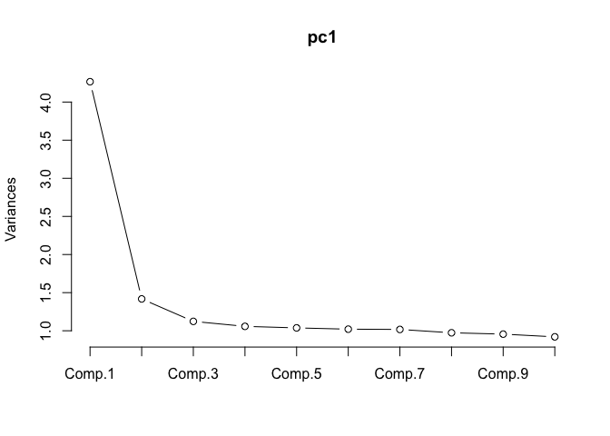

```r
plot(pc1,type="lines") # scree plot
```

```r
principal(x, nfactors=4, rotate="varimax")
```

```
Principal Components Analysis
Call: principal(r = x, nfactors = 4, rotate = "varimax")
Standardized loadings (pattern matrix) based upon correlation matrix
                          RC1   RC2   RC3   RC4    h2   u2 com
Age                      0.77  0.03  0.05  0.07 0.596 0.40 1.0
DailyRate                0.04 -0.06  0.07  0.63 0.413 0.59 1.1
DistanceFromHome        -0.04  0.08  0.55  0.06 0.311 0.69 1.1
EnvironmentSatisfaction  0.00 -0.01 -0.42  0.26 0.241 0.76 1.7
JobInvolvement          -0.02  0.01 -0.08  0.58 0.342 0.66 1.0
JobLevel                 0.89  0.25 -0.02 -0.03 0.860 0.14 1.2
JobSatisfaction          0.00 -0.02  0.26  0.03 0.069 0.93 1.0
MonthlyIncome            0.89  0.22 -0.02 -0.04 0.851 0.15 1.1
PercentSalaryHike       -0.04  0.01  0.55 -0.12 0.323 0.68 1.1
StockOptionLevel        -0.01  0.07  0.15  0.46 0.236 0.76 1.3
TotalWorkingYears        0.86  0.35  0.02  0.01 0.859 0.14 1.3
TrainingTimesLastYear   -0.06  0.03 -0.24 -0.08 0.068 0.93 1.4
WorkLifeBalance          0.00  0.04 -0.39 -0.20 0.190 0.81 1.5
YearsAtCompany           0.38  0.84 -0.03 -0.03 0.863 0.14 1.4
YearsInCurrentRole       0.20  0.88 -0.02  0.04 0.817 0.18 1.1
YearsWithCurrManager     0.18  0.89 -0.02  0.02 0.827 0.17 1.1

                       RC1  RC2  RC3  RC4
SS loadings           3.15 2.54 1.10 1.09
Proportion Var        0.20 0.16 0.07 0.07
Cumulative Var        0.20 0.36 0.42 0.49
Proportion Explained  0.40 0.32 0.14 0.14
Cumulative Proportion 0.40 0.72 0.86 1.00

Mean item complexity =  1.2
Test of the hypothesis that 4 components are sufficient.

The root mean square of the residuals (RMSR) is  0.08
 with the empirical chi square  2399.12  with prob <  0

Fit based upon off diagonal values = 0.88
```

```r
principal(x, nfactors=3, rotate="varimax")
```

```
Principal Components Analysis
Call: principal(r = x, nfactors = 3, rotate = "varimax")
Standardized loadings (pattern matrix) based upon correlation matrix
                          RC1   RC2   RC3    h2   u2 com
Age                      0.77  0.03  0.08 0.595 0.40 1.0
DailyRate                0.05 -0.05  0.47 0.230 0.77 1.0
DistanceFromHome        -0.04  0.07  0.45 0.206 0.79 1.1
EnvironmentSatisfaction  0.00  0.00 -0.14 0.020 0.98 1.0
JobInvolvement          -0.01  0.02  0.32 0.106 0.89 1.0
JobLevel                 0.89  0.25 -0.04 0.859 0.14 1.2
JobSatisfaction          0.00 -0.02  0.22 0.047 0.95 1.0
MonthlyIncome            0.89  0.22 -0.05 0.851 0.15 1.1
PercentSalaryHike       -0.04  0.00  0.33 0.112 0.89 1.0
StockOptionLevel        -0.01  0.08  0.42 0.179 0.82 1.1
TotalWorkingYears        0.86  0.35  0.01 0.859 0.14 1.3
TrainingTimesLastYear   -0.06  0.03 -0.23 0.057 0.94 1.2
WorkLifeBalance         -0.01  0.04 -0.42 0.179 0.82 1.0
YearsAtCompany           0.38  0.84 -0.04 0.862 0.14 1.4
YearsInCurrentRole       0.20  0.88  0.01 0.816 0.18 1.1
YearsWithCurrManager     0.18  0.89  0.00 0.827 0.17 1.1

                       RC1  RC2  RC3
SS loadings           3.15 2.54 1.12
Proportion Var        0.20 0.16 0.07
Cumulative Var        0.20 0.36 0.43
Proportion Explained  0.46 0.37 0.17
Cumulative Proportion 0.46 0.83 1.00

Mean item complexity =  1.1
Test of the hypothesis that 3 components are sufficient.

The root mean square of the residuals (RMSR) is  0.07
 with the empirical chi square  1613.89  with prob <  2.1e-287

Fit based upon off diagonal values = 0.92
```

```r
principal(x, nfactors=3, rotate="promax")
```

```
Principal Components Analysis
Call: principal(r = x, nfactors = 3, rotate = "promax")
Standardized loadings (pattern matrix) based upon correlation matrix
                          RC1   RC2   RC3    h2   u2 com
Age                      0.83 -0.17  0.08 0.595 0.40 1.1
DailyRate                0.05 -0.07  0.47 0.230 0.77 1.1
DistanceFromHome        -0.07  0.09  0.45 0.206 0.79 1.1
EnvironmentSatisfaction  0.00  0.00 -0.14 0.020 0.98 1.0
JobInvolvement          -0.03  0.03  0.33 0.106 0.89 1.0
JobLevel                 0.91  0.04 -0.04 0.859 0.14 1.0
JobSatisfaction          0.00 -0.03  0.22 0.047 0.95 1.0
MonthlyIncome            0.92  0.01 -0.04 0.851 0.15 1.0
PercentSalaryHike       -0.04  0.01  0.33 0.112 0.89 1.0
StockOptionLevel        -0.04  0.09  0.42 0.179 0.82 1.1
TotalWorkingYears        0.84  0.16  0.02 0.859 0.14 1.1
TrainingTimesLastYear   -0.07  0.05 -0.23 0.057 0.94 1.3
WorkLifeBalance         -0.01  0.05 -0.42 0.179 0.82 1.0
YearsAtCompany           0.20  0.82 -0.03 0.862 0.14 1.1
YearsInCurrentRole      -0.02  0.91  0.03 0.816 0.18 1.0
YearsWithCurrManager    -0.04  0.93  0.01 0.827 0.17 1.0

                       RC1  RC2  RC3
SS loadings           3.18 2.51 1.12
Proportion Var        0.20 0.16 0.07
Cumulative Var        0.20 0.36 0.43
Proportion Explained  0.47 0.37 0.17
Cumulative Proportion 0.47 0.83 1.00

 With component correlations of
     RC1   RC2   RC3
RC1 1.00  0.45  0.02
RC2 0.45  1.00 -0.01
RC3 0.02 -0.01  1.00

Mean item complexity =  1.1
Test of the hypothesis that 3 components are sufficient.

The root mean square of the residuals (RMSR) is  0.07
 with the empirical chi square  1613.89  with prob <  2.1e-287

Fit based upon off diagonal values = 0.92
```

```r
principal(x, nfactors=2, rotate="promax")
```

```
Principal Components Analysis
Call: principal(r = x, nfactors = 2, rotate = "promax")
Standardized loadings (pattern matrix) based upon correlation matrix
                          RC1   RC2      h2   u2 com
Age                      0.82 -0.18 5.9e-01 0.41 1.1
DailyRate                0.07 -0.09 7.8e-03 0.99 1.9
DistanceFromHome        -0.05  0.07 4.1e-03 1.00 1.8
EnvironmentSatisfaction  0.00  0.01 8.1e-05 1.00 1.3
JobInvolvement          -0.01  0.01 1.7e-04 1.00 2.0
JobLevel                 0.92  0.03 8.6e-01 0.14 1.0
JobSatisfaction          0.01 -0.04 1.1e-03 1.00 1.2
MonthlyIncome            0.92 -0.01 8.5e-01 0.15 1.0
PercentSalaryHike       -0.03 -0.01 1.2e-03 1.00 1.1
StockOptionLevel        -0.02  0.07 4.0e-03 1.00 1.1
TotalWorkingYears        0.86  0.14 8.6e-01 0.14 1.0
TrainingTimesLastYear   -0.07  0.06 5.4e-03 0.99 1.9
WorkLifeBalance         -0.02  0.07 3.9e-03 1.00 1.2
YearsAtCompany           0.27  0.79 8.6e-01 0.14 1.2
YearsInCurrentRole       0.06  0.88 8.1e-01 0.19 1.0
YearsWithCurrManager     0.04  0.89 8.3e-01 0.17 1.0

                       RC1  RC2
SS loadings           3.31 2.37
Proportion Var        0.21 0.15
Cumulative Var        0.21 0.36
Proportion Explained  0.58 0.42
Cumulative Proportion 0.58 1.00

 With component correlations of
    RC1 RC2
RC1 1.0 0.4
RC2 0.4 1.0

Mean item complexity =  1.3
Test of the hypothesis that 2 components are sufficient.

The root mean square of the residuals (RMSR) is  0.04
 with the empirical chi square  472.28  with prob <  1.5e-53

Fit based upon off diagonal values = 0.98
```

#### Observations from intercorrelation of predictors

Among continuous variables there appears to be a significant relationship among variables associated with age and moderate intercorrelations among other factors. Exploratory factor analysis was used to understand the common variance among these measures. Principal components analysis indicated that 2 to 4 factors may best explain the relationships. Scree plot suggests 3 but 2-4 were explored. Varimax and promax rotations were used to clarify the factor structure (varimax for orthogonal factors and promax for correlated factors) The PCA results clearly show 2 strong factors 1. Experience Level=age, Job Level, Monthly Income, Total Working Years 2. Company Experience= Years at Company, Years in Current Role, Years with Current Manager The Third factor is less well defined but relates to Economic and Living factors = daily rate, distance from home, Stock Option Level and negative Work Life Balance Four Factor solution differentiates this third factor into 1. Long Commute + Higher Pay Hike 2. Daily Rate + Job Involvement + Stock Option Level Only the two strong factors will be considered for combined factor scores.

###### Next Step create dummy coding for nominal variables so specific responses can be identified as contributing to attrition in the final analysis

Also create z-scores to allow for factor score generation, convert to a metric of mean=50 and sd=10 to eliminate negative values

```r
knitr::opts_chunk$set(echo = TRUE)


### normalize continous variables, use mean=50 and sd=10 to eliminate negative values
emp_data$agez <- (((emp_data$Age-mean(emp_data$Age))/sd(emp_data$Age) * 10) + 50)
emp_data$joblevelz <- (((emp_data$JobLevel-mean(emp_data$JobLevel))/sd(emp_data$JobLevel)*10)
               +50)
emp_data$monthlyincomez <- (((emp_data$MonthlyIncome-mean(emp_data$MonthlyIncome))/sd(emp_data$MonthlyIncome) * 10) + 50)
emp_data$totalworkingyearsz <- (((emp_data$TotalWorkingYears-mean(emp_data$TotalWorkingYears))/sd(emp_data$TotalWorkingYears) * 10) + 50)
emp_data$yearsatcompancyz <- (((emp_data$YearsAtCompany-mean(emp_data$YearsAtCompany))/sd(emp_data$YearsAtCompany) * 10) + 50)
emp_data$yearsincurrentrolez <- (((emp_data$YearsInCurrentRole-mean(emp_data$YearsInCurrentRole))/sd(emp_data$YearsInCurrentRole) * 10) + 50)
emp_data$yearswithcurrentmanagerz <- (((emp_data$YearsWithCurrManager-mean(emp_data$YearsWithCurrManager))/sd(emp_data$YearsWithCurrManager) * 10) + 50)

describe(emp_data$agez)
```

```
   vars    n mean sd median trimmed  mad   min   max range skew kurtosis
X1    1 1470   50 10  48.99    49.5 9.74 29.29 75.26 45.98 0.41    -0.41
     se
X1 0.26
```

```r
describe(emp_data$joblevelz)
```

```
   vars    n mean sd median trimmed   mad   min   max range skew kurtosis
X1    1 1470   50 10  49.42   48.49 13.39 40.39 76.52 36.14 1.02     0.39
     se
X1 0.26
```

```r
describe(emp_data$monthlyincomez)
```

```
   vars    n mean sd median trimmed  mad   min   max range skew kurtosis
X1    1 1470   50 10  46.64   48.22 6.92 38.33 78.67 40.34 1.37     0.99
     se
X1 0.26
```

```r
describe(emp_data$totalworkingyearsz)
```

```
   vars    n mean sd median trimmed  mad  min   max range skew kurtosis
X1    1 1470   50 10  48.36   48.83 7.62 35.5 86.91 51.41 1.11     0.91
     se
X1 0.26
```

```r
describe(emp_data$yearsatcompancyz)
```

```
   vars    n mean sd median trimmed  mad   min    max range skew kurtosis
X1    1 1470   50 10  46.72   48.33 7.26 38.56 103.85 65.29 1.76     3.91
     se
X1 0.26
```

```r
describe(emp_data$yearsincurrentrolez)
```

```
   vars    n mean sd median trimmed   mad   min   max range skew kurtosis
X1    1 1470   50 10  46.61   48.97 12.28 38.33 88.01 49.68 0.92     0.47
     se
X1 0.26
```

```r
describe(emp_data$yearswithcurrentmanagerz)
```

```
   vars    n mean sd median trimmed   mad   min   max range skew kurtosis
X1    1 1470   50 10  46.85   49.01 12.47 38.44 86.09 47.64 0.83     0.16
     se
X1 0.26
```

```r
##### create factor scores

emp_data$Experience <- (emp_data$agez + emp_data$joblevelz + emp_data$monthlyincomez + emp_data$totalworkingyearsz)/4
emp_data$CompanyExp <- (emp_data$yearsatcompancyz + emp_data$yearsincurrentrolez + emp_data$yearswithcurrentmanagerz)/3

describe(emp_data$Experience)
```

```
   vars    n mean  sd median trimmed  mad  min   max range skew kurtosis
X1    1 1470   50 8.8  48.18   48.92 7.12 35.9 78.39 42.49 1.03     0.49
     se
X1 0.23
```

```r
describe(emp_data$CompanyExp)
```

```
   vars    n mean   sd median trimmed  mad   min   max range skew kurtosis
X1    1 1470   50 9.12  47.03   49.04 8.39 38.44 81.37 42.92 0.85     0.02
     se
X1 0.24
```

```r
##### Create Dummy variables
emp_data$sex[emp_data$Gender=="Female"]  = 2
emp_data$sex[emp_data$Gender=="Male"]  = 1
emp_data$sex <- as.numeric(emp_data$sex)
FreqTable(emp_data$sex)
```

```
  X Freq CumFreq Prop CumProp
1 1  882     882  0.6     0.6
2 2  588    1470  0.4     1.0
```

```r
emp_data$AttNum[emp_data$Attrition=="Yes"]  = 1
emp_data$AttNum[emp_data$Attrition=="No"]  = 0
emp_data$AttNum <- as.factor(emp_data$AttNum)
FreqTable(emp_data$AttNum)
```

```
  X Freq CumFreq      Prop   CumProp
1 0 1233    1233 0.8387755 0.8387755
2 1  237    1470 0.1612245 1.0000000
```

```r
emp_data$FreqTravel <- 0
emp_data$FreqTravel[emp_data$BusinessTravel=="Travel_Frequently"]  = 1
emp_data$FreqTravel <- as.numeric(emp_data$FreqTravel)
FreqTable(emp_data$FreqTravel)
```

```
  X Freq CumFreq      Prop   CumProp
1 0 1193    1193 0.8115646 0.8115646
2 1  277    1470 0.1884354 1.0000000
```

```r
emp_data$NonTravel <- 0
emp_data$NonTravel[emp_data$BusinessTravel=="Non-Travel"]  = 1
emp_data$NonTravel <- as.numeric(emp_data$NonTravel)
FreqTable(emp_data$NonTravel)
```

```
  X Freq CumFreq      Prop   CumProp
1 0 1320    1320 0.8979592 0.8979592
2 1  150    1470 0.1020408 1.0000000
```

```r
emp_data$RDDept <- 0
emp_data$RDDept[emp_data$Department=="Research & Development"]  = 1
emp_data$RDDept <- as.factor(emp_data$RDDept)
FreqTable(emp_data$RDDept)
```

```
  X Freq CumFreq      Prop   CumProp
1 0  509     509 0.3462585 0.3462585
2 1  961    1470 0.6537415 1.0000000
```

```r
emp_data$HRdegree <- 0
emp_data$HRdegree[emp_data$EducationField=="Human Resources"]  = 1
emp_data$HRdegree <- as.factor(emp_data$HRdegree)
FreqTable(emp_data$HRdegree)
```

```
  X Freq CumFreq       Prop   CumProp
1 0 1443    1443 0.98163265 0.9816327
2 1   27    1470 0.01836735 1.0000000
```

```r
emp_data$LSdegree <- 0
emp_data$LSdegree[emp_data$EducationField=="Life Sciences"]  = 1
emp_data$LSdegree <- as.factor(emp_data$LSdegree)
FreqTable(emp_data$LSdegree)
```

```
  X Freq CumFreq      Prop   CumProp
1 0  864     864 0.5877551 0.5877551
2 1  606    1470 0.4122449 1.0000000
```

```r
emp_data$MKdegree <- 0
emp_data$MKdegree[emp_data$EducationField=="Marketing"]  = 1
emp_data$MKdegree <- as.factor(emp_data$MKdegree)
FreqTable(emp_data$MKdegree)
```

```
  X Freq CumFreq      Prop   CumProp
1 0 1311    1311 0.8918367 0.8918367
2 1  159    1470 0.1081633 1.0000000
```

```r
emp_data$MDdegree <- 0
emp_data$MDdegree[emp_data$EducationField=="Medical"]  = 1
emp_data$MDdegree <- as.factor(emp_data$MDdegree)
FreqTable(emp_data$MDdegree)
```

```
  X Freq CumFreq      Prop   CumProp
1 0 1006    1006 0.6843537 0.6843537
2 1  464    1470 0.3156463 1.0000000
```

```r
emp_data$HeathREPjob <- 0
emp_data$HeathREPjob[emp_data$JobRole=="Healthcare Representative"]  = 1
emp_data$HeathREPjob <- as.factor(emp_data$HeathREPjob)
FreqTable(emp_data$HeathREPjob)
```

```
  X Freq CumFreq       Prop   CumProp
1 0 1339    1339 0.91088435 0.9108844
2 1  131    1470 0.08911565 1.0000000
```

```r
emp_data$HRjob <- 0
emp_data$HRjob[emp_data$JobRole=="Human Resources"]  = 1
emp_data$HRjob <- as.factor(emp_data$HRjob)
FreqTable(emp_data$HRjob)
```

```
  X Freq CumFreq       Prop   CumProp
1 0 1418    1418 0.96462585 0.9646259
2 1   52    1470 0.03537415 1.0000000
```

```r
emp_data$LabTechjob <- 0
emp_data$LabTechjob[emp_data$JobRole=="Laboratory Technician"]  = 1
emp_data$LabTechjob <- as.factor(emp_data$LabTechjob)
FreqTable(emp_data$LabTechjob)
```

```
  X Freq CumFreq      Prop   CumProp
1 0 1211    1211 0.8238095 0.8238095
2 1  259    1470 0.1761905 1.0000000
```

```r
emp_data$Managerjob <- 0
emp_data$Managerjob[emp_data$JobRole=="Manager"]  = 1
emp_data$Managerjob <- as.factor(emp_data$Managerjob)
FreqTable(emp_data$Managerjob)
```

```
  X Freq CumFreq       Prop   CumProp
1 0 1368    1368 0.93061224 0.9306122
2 1  102    1470 0.06938776 1.0000000
```

```r
emp_data$ManDirjob <- 0
emp_data$ManDirjob[emp_data$JobRole=="Manufacturing Director"]  = 1
emp_data$ManDirjob <- as.factor(emp_data$ManDirjob)
FreqTable(emp_data$ManDirjob)
```

```
  X Freq CumFreq       Prop   CumProp
1 0 1325    1325 0.90136054 0.9013605
2 1  145    1470 0.09863946 1.0000000
```

```r
emp_data$ResDirjob <- 0
emp_data$ResDirjob[emp_data$JobRole=="Research Director"]  = 1
emp_data$ResDirjob <- as.factor(emp_data$ResDirjob)
FreqTable(emp_data$ResDirjob)
```

```
  X Freq CumFreq       Prop   CumProp
1 0 1390    1390 0.94557823 0.9455782
2 1   80    1470 0.05442177 1.0000000
```

```r
emp_data$ResScijob <- 0
emp_data$ResScijob[emp_data$JobRole=="Research Scientist"]  = 1
emp_data$ResScijob <- as.factor(emp_data$ResScijob)
FreqTable(emp_data$ResScijob)
```

```
  X Freq CumFreq      Prop   CumProp
1 0 1178    1178 0.8013605 0.8013605
2 1  292    1470 0.1986395 1.0000000
```

```r
emp_data$SalExecjob <- 0
emp_data$SalExecjob[emp_data$JobRole=="Sales Executive"]  = 1
emp_data$SalExecjob <- as.factor(emp_data$SalExecjob)
FreqTable(emp_data$SalExecjob)
```

```
  X Freq CumFreq      Prop   CumProp
1 0 1144    1144 0.7782313 0.7782313
2 1  326    1470 0.2217687 1.0000000
```

```r
emp_data$SalRepjob <- 0
emp_data$SalRepjob[emp_data$JobRole=="Sales Representative"]  = 1
emp_data$SalRepjob <- as.factor(emp_data$SalRepjob)
FreqTable(emp_data$SalRepjob)
```

```
  X Freq CumFreq       Prop   CumProp
1 0 1387    1387 0.94353741 0.9435374
2 1   83    1470 0.05646259 1.0000000
```

```r
emp_data$Married <- 0
emp_data$Married[emp_data$MaritalStatus=="Married"]  = 1
emp_data$Married<- as.numeric(emp_data$Married)
FreqTable(emp_data$Married)
```

```
  X Freq CumFreq      Prop   CumProp
1 0  797     797 0.5421769 0.5421769
2 1  673    1470 0.4578231 1.0000000
```

```r
emp_data$Single <- 0
emp_data$Single[emp_data$MaritalStatus=="Single"]  = 1
emp_data$Single<- as.numeric(emp_data$Single)
FreqTable(emp_data$Single)
```

```
  X Freq CumFreq      Prop   CumProp
1 0 1000    1000 0.6802721 0.6802721
2 1  470    1470 0.3197279 1.0000000
```

```r
emp_data$OT <- 0
emp_data$OT[emp_data$OverTime=="Yes"]  = 1
emp_data$OT<- as.numeric(emp_data$OT)
FreqTable(emp_data$OT)
```

```
  X Freq CumFreq      Prop   CumProp
1 0 1054    1054 0.7170068 0.7170068
2 1  416    1470 0.2829932 1.0000000
```

```r
#### create sex interactions

emp_data$SexbyOT <- emp_data$sex*emp_data$OT
emp_data$SexbyMarried <- emp_data$sex * emp_data$Married
emp_data$SexbySingle <- emp_data$sex * emp_data$Single
emp_data$SexbyFreqTrav <- emp_data$sex * emp_data$FreqTravel
emp_data$SexbyNonTrav <- emp_data$sex * emp_data$NonTravel
FreqTable(emp_data$SexbyOT)
```

```
  X Freq CumFreq      Prop   CumProp
1 0 1054    1054 0.7170068 0.7170068
2 1  236    1290 0.1605442 0.8775510
3 2  180    1470 0.1224490 1.0000000
```

```r
FreqTable(emp_data$SexbyMarried)
```

```
  X Freq CumFreq      Prop   CumProp
1 0  797     797 0.5421769 0.5421769
2 1  401    1198 0.2727891 0.8149660
3 2  272    1470 0.1850340 1.0000000
```

```r
FreqTable(emp_data$SexbySingle)
```

```
  X Freq CumFreq      Prop   CumProp
1 0 1000    1000 0.6802721 0.6802721
2 1  271    1271 0.1843537 0.8646259
3 2  199    1470 0.1353741 1.0000000
```

```r
FreqTable(emp_data$SexbyFreqTrav)
```

```
  X Freq CumFreq       Prop   CumProp
1 0 1193    1193 0.81156463 0.8115646
2 1  160    1353 0.10884354 0.9204082
3 2  117    1470 0.07959184 1.0000000
```

```r
FreqTable(emp_data$SexbyNonTrav)
```

```
  X Freq CumFreq       Prop   CumProp
1 0 1320    1320 0.89795918 0.8979592
2 1  101    1421 0.06870748 0.9666667
3 2   49    1470 0.03333333 1.0000000
```

#### Next Step is subset the data into a training and test sets

```r
knitr::opts_chunk$set(echo = TRUE)

set.seed(50)
subset1 <- sample.int(n = nrow(emp_data), size = floor(.75*nrow(emp_data)), replace = F)
emp_datatrain <- emp_data[subset1, ]
emp_datatest  <- emp_data[-subset1, ]
str(emp_datatrain)
```

```
Classes 'tbl_df', 'tbl' and 'data.frame':   1102 obs. of  70 variables:
 $ Age                     : num  28 38 26 29 36 55 47 50 38 58 ...
 $ Attrition               : chr  "No" "No" "Yes" "No" ...
 $ BusinessTravel          : chr  "Travel_Rarely" "Travel_Rarely" "Travel_Rarely" "Travel_Frequently" ...
 $ DailyRate               : num  866 395 950 995 885 ...
 $ Department              : chr  "Sales" "Sales" "Sales" "Research & Development" ...
 $ DistanceFromHome        : num  5 9 4 2 16 8 2 28 29 9 ...
 $ Education               : num  3 3 4 1 4 3 4 3 5 3 ...
 $ EducationField          : chr  "Medical" "Marketing" "Marketing" "Life Sciences" ...
 $ EmployeeCount           : num  1 1 1 1 1 1 1 1 1 1 ...
 $ EmployeeNumber          : num  1469 893 401 1590 1042 ...
 $ EnvironmentSatisfaction : num  4 2 4 1 3 4 1 4 4 2 ...
 $ Gender                  : chr  "Male" "Male" "Male" "Male" ...
 $ HourlyRate              : num  84 98 48 87 43 33 82 43 50 75 ...
 $ JobInvolvement          : num  3 2 2 3 4 3 3 3 3 2 ...
```

[output cut: 56 more lines]

```r
str(emp_datatest)
```

```
Classes 'tbl_df', 'tbl' and 'data.frame':   368 obs. of  70 variables:
 $ Age                     : num  38 34 44 46 44 33 35 41 37 26 ...
 $ Attrition               : chr  "No" "Yes" "No" "No" ...
 $ BusinessTravel          : chr  "Travel_Rarely" "Travel_Rarely" "Travel_Rarely" "Travel_Rarely" ...
 $ DailyRate               : num  371 699 477 705 1459 ...
 $ Department              : chr  "Research & Development" "Research & Development" "Research & Development" "Sales" ...
 $ DistanceFromHome        : num  2 6 7 2 10 1 4 12 19 23 ...
 $ Education               : num  3 1 4 4 4 3 2 3 2 3 ...
 $ EducationField          : chr  "Life Sciences" "Medical" "Medical" "Marketing" ...
 $ EmployeeCount           : num  1 1 1 1 1 1 1 1 1 1 ...
 $ EmployeeNumber          : num  24 31 36 38 40 52 53 58 61 72 ...
 $ EnvironmentSatisfaction : num  4 2 1 2 4 3 3 2 2 3 ...
 $ Gender                  : chr  "Male" "Male" "Female" "Female" ...
 $ HourlyRate              : num  45 83 42 83 41 42 75 49 73 47 ...
 $ JobInvolvement          : num  3 3 2 3 3 4 3 3 3 2 ...
```

[output cut: 56 more lines]

#### Next Step - Model exploration using logistic regression

logistic regression was selected as a procedure that specifically addresses binomial probability prediction

Model 1: all individual variables, that is non of the combined factors or interactions are included. Model 2: dropping individual z-scores from the factors and using the factor scores.  
Model 3: all individual variables adding in sex interactions

```r
knitr::opts_chunk$set(echo = TRUE)

logout1 <- glm(AttNum ~OT + Single + Married + SalRepjob + SalExecjob + ResScijob + ResDirjob + ManDirjob + Managerjob +
                 LabTechjob + HRjob + HeathREPjob + MDdegree + MKdegree + LSdegree + HRdegree + RDDept + NonTravel + FreqTravel
               + sex + agez + joblevelz + monthlyincomez + totalworkingyearsz + yearsatcompancyz + yearsincurrentrolez + yearswithcurrentmanagerz
               + DailyRate + DistanceFromHome + EnvironmentSatisfaction + JobInvolvement + JobSatisfaction + RelationshipSatisfaction
               + StockOptionLevel + TrainingTimesLastYear + WorkLifeBalance, data=emp_datatrain, family=binomial(link="logit"))
summary(logout1)
```

```
Call:
glm(formula = AttNum ~ OT + Single + Married + SalRepjob + SalExecjob +
    ResScijob + ResDirjob + ManDirjob + Managerjob + LabTechjob +
    HRjob + HeathREPjob + MDdegree + MKdegree + LSdegree + HRdegree +
    RDDept + NonTravel + FreqTravel + sex + agez + joblevelz +
    monthlyincomez + totalworkingyearsz + yearsatcompancyz +
    yearsincurrentrolez + yearswithcurrentmanagerz + DailyRate +
    DistanceFromHome + EnvironmentSatisfaction + JobInvolvement +
    JobSatisfaction + RelationshipSatisfaction + StockOptionLevel +
    TrainingTimesLastYear + WorkLifeBalance, family = binomial(link = "logit"),
    data = emp_datatrain)

Deviance Residuals:
    Min       1Q   Median       3Q      Max
-1.7910  -0.4937  -0.2566  -0.0971   3.3112

Coefficients: (1 not defined because of singularities)
                           Estimate Std. Error z value Pr(>|z|)
(Intercept)               4.7083352  2.2343585   2.107 0.035097 *
OT                        1.8939542  0.2213222   8.557  < 2e-16 ***
Single                    1.3258324  0.4071433   3.256 0.001128 **
Married                   0.6275211  0.3177968   1.975 0.048314 *
SalRepjob1                3.7456243  1.5231858   2.459 0.013930 *
SalExecjob1               2.6848573  1.4599804   1.839 0.065920 .
ResScijob1                0.8201136  0.5813237   1.411 0.158313
ResDirjob1               -1.1713697  1.2545497  -0.934 0.350460
ManDirjob1                0.6887358  0.6143424   1.121 0.262248
Managerjob1               0.7567989  1.0653684   0.710 0.477479
LabTechjob1               1.9513304  0.5693690   3.427 0.000610 ***
HRjob1                    2.5107967  1.5526190   1.617 0.105849
HeathREPjob1                     NA         NA      NA       NA
MDdegree1                -0.8358090  0.3255528  -2.567 0.010248 *
MKdegree1                -0.5283022  0.4305665  -1.227 0.219825
LSdegree1                -0.5580835  0.3031323  -1.841 0.065613 .
HRdegree1                 0.2452517  0.9059296   0.271 0.786608
RDDept1                   1.1470744  1.3744085   0.835 0.403946
NonTravel                -0.8657802  0.4609870  -1.878 0.060367 .
FreqTravel                0.8539119  0.2408435   3.546 0.000392 ***
sex                      -0.2725974  0.2125283  -1.283 0.199618
agez                     -0.0201914  0.0143051  -1.411 0.158101
```

[output cut: 10 more lines]

```
JobSatisfaction          -0.4434118  0.0933541  -4.750 2.04e-06 ***
RelationshipSatisfaction -0.3159182  0.0947332  -3.335 0.000854 ***
StockOptionLevel         -0.0867734  0.1799335  -0.482 0.629627
TrainingTimesLastYear    -0.2382817  0.0854690  -2.788 0.005305 **
WorkLifeBalance          -0.3924259  0.1407163  -2.789 0.005291 **
---
Signif. codes:  0 '***' 0.001 '**' 0.01 '*' 0.05 '.' 0.1 ' ' 1

(Dispersion parameter for binomial family taken to be 1)

    Null deviance: 974.59  on 1101  degrees of freedom
Residual deviance: 655.37  on 1066  degrees of freedom
AIC: 727.37

Number of Fisher Scoring iterations: 7
```

```r
logout2 <- glm(AttNum ~OT + Single + Married + SalRepjob + SalExecjob + ResScijob + ResDirjob + ManDirjob + Managerjob +
                 LabTechjob + HRjob + HeathREPjob + MDdegree + MKdegree + LSdegree + HRdegree + RDDept + NonTravel + FreqTravel
               + sex + agez + Experience + CompanyExp
               + DailyRate + DistanceFromHome + EnvironmentSatisfaction + JobInvolvement + JobSatisfaction + RelationshipSatisfaction
               + StockOptionLevel + TrainingTimesLastYear + WorkLifeBalance, data=emp_datatrain, family=binomial(link="logit"))
summary(logout2)
```

```
Call:
glm(formula = AttNum ~ OT + Single + Married + SalRepjob + SalExecjob +
    ResScijob + ResDirjob + ManDirjob + Managerjob + LabTechjob +
    HRjob + HeathREPjob + MDdegree + MKdegree + LSdegree + HRdegree +
    RDDept + NonTravel + FreqTravel + sex + agez + Experience +
    CompanyExp + DailyRate + DistanceFromHome + EnvironmentSatisfaction +
    JobInvolvement + JobSatisfaction + RelationshipSatisfaction +
    StockOptionLevel + TrainingTimesLastYear + WorkLifeBalance,
    family = binomial(link = "logit"), data = emp_datatrain)

Deviance Residuals:
    Min       1Q   Median       3Q      Max
-1.8112  -0.4958  -0.2698  -0.1063   3.2672

Coefficients: (1 not defined because of singularities)
                           Estimate Std. Error z value Pr(>|z|)
(Intercept)               4.3024938  2.1049592   2.044 0.040956 *
OT                        1.8685942  0.2192641   8.522  < 2e-16 ***
Single                    1.2843456  0.4044784   3.175 0.001497 **
Married                   0.6000441  0.3163470   1.897 0.057856 .
SalRepjob1                3.8185343  1.5237492   2.506 0.012210 *
SalExecjob1               2.6622777  1.4643690   1.818 0.069058 .
ResScijob1                0.9198401  0.5624309   1.635 0.101950
ResDirjob1               -1.2878680  1.2047634  -1.069 0.285079
ManDirjob1                0.6584452  0.6128171   1.074 0.282618
Managerjob1               0.9762508  0.9847121   0.991 0.321487
LabTechjob1               2.0412170  0.5549414   3.678 0.000235 ***
HRjob1                    2.6838447  1.5462970   1.736 0.082624 .
HeathREPjob1                     NA         NA      NA       NA
MDdegree1                -0.7347203  0.3216136  -2.284 0.022343 *
MKdegree1                -0.4640304  0.4255558  -1.090 0.275532
LSdegree1                -0.5048345  0.3007001  -1.679 0.093179 .
HRdegree1                 0.1841377  0.8948956   0.206 0.836975
RDDept1                   1.1326783  1.3748713   0.824 0.410029
NonTravel                -0.8186569  0.4540639  -1.803 0.071395 .
FreqTravel                0.8631188  0.2379073   3.628 0.000286 ***
sex                      -0.2609511  0.2108801  -1.237 0.215924
agez                     -0.0233254  0.0198310  -1.176 0.239512
Experience                0.0092798  0.0385009   0.241 0.809533
CompanyExp               -0.0497973  0.0157494  -3.162 0.001568 **
DailyRate                -0.0001850  0.0002532  -0.730 0.465090
DistanceFromHome          0.0362287  0.0123450   2.935 0.003339 **
EnvironmentSatisfaction  -0.3687475  0.0927012  -3.978 6.96e-05 ***
JobInvolvement           -0.6165610  0.1397787  -4.411 1.03e-05 ***
JobSatisfaction          -0.4284212  0.0919581  -4.659 3.18e-06 ***
RelationshipSatisfaction -0.3127149  0.0941453  -3.322 0.000895 ***
StockOptionLevel         -0.0932714  0.1787490  -0.522 0.601809
TrainingTimesLastYear    -0.2252975  0.0844962  -2.666 0.007668 **
WorkLifeBalance          -0.4042802  0.1404767  -2.878 0.004003 **
---
Signif. codes:  0 '***' 0.001 '**' 0.01 '*' 0.05 '.' 0.1 ' ' 1

(Dispersion parameter for binomial family taken to be 1)

    Null deviance: 974.59  on 1101  degrees of freedom
Residual deviance: 661.61  on 1070  degrees of freedom
AIC: 725.61

Number of Fisher Scoring iterations: 7
```

```r
logout3 <- glm(AttNum ~OT + Single + Married + SalRepjob + SalExecjob + ResScijob + ResDirjob + ManDirjob + Managerjob +
                 LabTechjob + HRjob + HeathREPjob + MDdegree + MKdegree + LSdegree + HRdegree + RDDept + NonTravel + FreqTravel
               + sex + agez + joblevelz + monthlyincomez + totalworkingyearsz + yearsatcompancyz + yearsincurrentrolez + yearswithcurrentmanagerz
               + DailyRate + DistanceFromHome + EnvironmentSatisfaction + JobInvolvement + JobSatisfaction + RelationshipSatisfaction
               + StockOptionLevel + TrainingTimesLastYear + WorkLifeBalance + SexbyOT + SexbyMarried + SexbySingle + SexbyFreqTrav
               + SexbyNonTrav, data=emp_datatrain, family=binomial(link="logit"))
summary(logout3)
```

```
Call:
glm(formula = AttNum ~ OT + Single + Married + SalRepjob + SalExecjob +
    ResScijob + ResDirjob + ManDirjob + Managerjob + LabTechjob +
    HRjob + HeathREPjob + MDdegree + MKdegree + LSdegree + HRdegree +
    RDDept + NonTravel + FreqTravel + sex + agez + joblevelz +
    monthlyincomez + totalworkingyearsz + yearsatcompancyz +
    yearsincurrentrolez + yearswithcurrentmanagerz + DailyRate +
    DistanceFromHome + EnvironmentSatisfaction + JobInvolvement +
    JobSatisfaction + RelationshipSatisfaction + StockOptionLevel +
    TrainingTimesLastYear + WorkLifeBalance + SexbyOT + SexbyMarried +
    SexbySingle + SexbyFreqTrav + SexbyNonTrav, family = binomial(link = "logit"),
    data = emp_datatrain)

Deviance Residuals:
    Min       1Q   Median       3Q      Max
-1.7450  -0.4944  -0.2559  -0.0955   3.2975

Coefficients: (1 not defined because of singularities)
                           Estimate Std. Error z value Pr(>|z|)
(Intercept)               4.8489757  2.3514206   2.062 0.039194 *
OT                        2.4734591  0.6436118   3.843 0.000121 ***
Single                    1.3850831  0.9629114   1.438 0.150311
Married                   0.4957528  0.9363510   0.529 0.596492
SalRepjob1                3.7010728  1.5184653   2.437 0.014794 *
SalExecjob1               2.6149174  1.4569522   1.795 0.072688 .
ResScijob1                0.8381531  0.5863260   1.430 0.152861
ResDirjob1               -1.2634091  1.2674884  -0.997 0.318871
ManDirjob1                0.7240442  0.6169906   1.174 0.240592
Managerjob1               0.7209726  1.0699088   0.674 0.500398
LabTechjob1               1.9608967  0.5745381   3.413 0.000643 ***
HRjob1                    2.4662313  1.5453006   1.596 0.110499
HeathREPjob1                     NA         NA      NA       NA
MDdegree1                -0.8795773  0.3293726  -2.670 0.007575 **
MKdegree1                -0.5964124  0.4347470  -1.372 0.170107
LSdegree1                -0.5746830  0.3048366  -1.885 0.059401 .
HRdegree1                 0.1584828  0.9105311   0.174 0.861822
RDDept1                   1.0704080  1.3681586   0.782 0.433996
NonTravel                -0.8447309  1.3689918  -0.617 0.537204
FreqTravel                0.0669992  0.7255637   0.092 0.926427
sex                      -0.2589254  0.6159881  -0.420 0.674236
```

[output cut: 16 more lines]

```
SexbyOT                  -0.3971183  0.4305123  -0.922 0.356303
SexbyMarried              0.1028992  0.6418915   0.160 0.872640
SexbySingle              -0.0467217  0.6363742  -0.073 0.941473
SexbyFreqTrav             0.5573399  0.4884614   1.141 0.253865
SexbyNonTrav             -0.0151105  0.9939986  -0.015 0.987871
---
Signif. codes:  0 '***' 0.001 '**' 0.01 '*' 0.05 '.' 0.1 ' ' 1

(Dispersion parameter for binomial family taken to be 1)

    Null deviance: 974.59  on 1101  degrees of freedom
Residual deviance: 653.01  on 1061  degrees of freedom
AIC: 735.01

Number of Fisher Scoring iterations: 7
```

### Initial model exploration indicated that model 1 and model 2 performed nearly identially with AIC = 727 and AIC = 725 with slightly worse at Model 3 AIC= 735.

#### Next step improve the parsimony of the model and cross-validate the results

1. rerun analysis dropping non-significant variables where p > .10 and using non-transformed scores (e.g. dropping standardized (z) scores)
2. re-evaluate results and determine if variable significance level changes in reduced model
3. rerun analysis with variables p < .05 only
4. use test data set to evaluate model implementation.

```r
knitr::opts_chunk$set(echo = TRUE)

logout4 <- glm(AttNum ~OT + Single + Married + SalExecjob +SalRepjob + LabTechjob + MDdegree + LSdegree + NonTravel + FreqTravel + YearsAtCompany
                + YearsInCurrentRole + DistanceFromHome + EnvironmentSatisfaction + JobInvolvement + JobSatisfaction + RelationshipSatisfaction
                + TrainingTimesLastYear + WorkLifeBalance, data=emp_datatrain, family=binomial(link="logit"))
summary(logout4)
```

```
Call:
glm(formula = AttNum ~ OT + Single + Married + SalExecjob + SalRepjob +
    LabTechjob + MDdegree + LSdegree + NonTravel + FreqTravel +
    YearsAtCompany + YearsInCurrentRole + DistanceFromHome +
    EnvironmentSatisfaction + JobInvolvement + JobSatisfaction +
    RelationshipSatisfaction + TrainingTimesLastYear + WorkLifeBalance,
    family = binomial(link = "logit"), data = emp_datatrain)

Deviance Residuals:
    Min       1Q   Median       3Q      Max
-1.8779  -0.5120  -0.2879  -0.1331   3.0316

Coefficients:
                          Estimate Std. Error z value Pr(>|z|)
(Intercept)               2.794518   0.782926   3.569 0.000358 ***
OT                        1.783396   0.211738   8.423  < 2e-16 ***
Single                    1.441324   0.299514   4.812 1.49e-06 ***
Married                   0.630794   0.297462   2.121 0.033957 *
SalExecjob1               0.676441   0.263553   2.567 0.010269 *
SalRepjob1                1.958687   0.368862   5.310 1.10e-07 ***
LabTechjob1               1.388447   0.259161   5.357 8.44e-08 ***
MDdegree1                -0.780876   0.272678  -2.864 0.004187 **
LSdegree1                -0.464264   0.243465  -1.907 0.056533 .
NonTravel                -0.843253   0.449552  -1.876 0.060688 .
FreqTravel                0.784934   0.230589   3.404 0.000664 ***
YearsAtCompany            0.006972   0.029423   0.237 0.812700
YearsInCurrentRole       -0.158331   0.050239  -3.152 0.001624 **
DistanceFromHome          0.032528   0.011924   2.728 0.006371 **
EnvironmentSatisfaction  -0.341518   0.089868  -3.800 0.000145 ***
JobInvolvement           -0.651017   0.138668  -4.695 2.67e-06 ***
JobSatisfaction          -0.410545   0.089823  -4.571 4.86e-06 ***
RelationshipSatisfaction -0.287972   0.091303  -3.154 0.001610 **
TrainingTimesLastYear    -0.242855   0.083825  -2.897 0.003766 **
WorkLifeBalance          -0.357715   0.136543  -2.620 0.008798 **
---
Signif. codes:  0 '***' 0.001 '**' 0.01 '*' 0.05 '.' 0.1 ' ' 1

(Dispersion parameter for binomial family taken to be 1)

    Null deviance: 974.59  on 1101  degrees of freedom
Residual deviance: 683.57  on 1082  degrees of freedom
AIC: 723.57

Number of Fisher Scoring iterations: 6
```

```r
logout5 <- glm(AttNum ~OT + Single + Married + SalExecjob +SalRepjob + LabTechjob + MDdegree + FreqTravel + YearsInCurrentRole + DistanceFromHome
               + EnvironmentSatisfaction + JobInvolvement + JobSatisfaction + RelationshipSatisfaction
                + TrainingTimesLastYear + WorkLifeBalance, data=emp_datatrain, family=binomial(link="logit"))
summary(logout5)
```

```
Call:
glm(formula = AttNum ~ OT + Single + Married + SalExecjob + SalRepjob +
    LabTechjob + MDdegree + FreqTravel + YearsInCurrentRole +
    DistanceFromHome + EnvironmentSatisfaction + JobInvolvement +
    JobSatisfaction + RelationshipSatisfaction + TrainingTimesLastYear +
    WorkLifeBalance, family = binomial(link = "logit"), data = emp_datatrain)

Deviance Residuals:
    Min       1Q   Median       3Q      Max
-1.8364  -0.5194  -0.2883  -0.1411   3.0501

Coefficients:
                         Estimate Std. Error z value Pr(>|z|)
(Intercept)               2.33617    0.75476   3.095 0.001966 **
OT                        1.78708    0.20949   8.530  < 2e-16 ***
Single                    1.39416    0.29527   4.722 2.34e-06 ***
Married                   0.61606    0.29394   2.096 0.036095 *
SalExecjob1               0.74596    0.25669   2.906 0.003661 **
SalRepjob1                2.03063    0.36162   5.615 1.96e-08 ***
LabTechjob1               1.33550    0.25486   5.240 1.60e-07 ***
MDdegree1                -0.47869    0.22384  -2.139 0.032474 *
FreqTravel                0.86222    0.22768   3.787 0.000152 ***
YearsInCurrentRole       -0.14625    0.03433  -4.261 2.04e-05 ***
DistanceFromHome          0.02981    0.01179   2.528 0.011459 *
EnvironmentSatisfaction  -0.31757    0.08880  -3.576 0.000348 ***
JobInvolvement           -0.64449    0.13667  -4.716 2.41e-06 ***
JobSatisfaction          -0.41095    0.08956  -4.588 4.47e-06 ***
RelationshipSatisfaction -0.29000    0.09088  -3.191 0.001417 **
TrainingTimesLastYear    -0.23590    0.08311  -2.839 0.004533 **
WorkLifeBalance          -0.33741    0.13617  -2.478 0.013216 *
---
Signif. codes:  0 '***' 0.001 '**' 0.01 '*' 0.05 '.' 0.1 ' ' 1

(Dispersion parameter for binomial family taken to be 1)

    Null deviance: 974.59  on 1101  degrees of freedom
Residual deviance: 691.51  on 1085  degrees of freedom
AIC: 725.51

Number of Fisher Scoring iterations: 6
```

```r
emp_datatrain$pred1 <- logout1$fitted.values
emp_datatrain$Class1 <- 0
emp_datatrain$Class1[emp_datatrain$pred1 >= .50]  = 1
mftr1 <-CrossTable(emp_datatrain$AttNum, emp_datatrain$Class1)
```

```
   Cell Contents
|-------------------------|
|                       N |
| Chi-square contribution |
|           N / Row Total |
|           N / Col Total |
|         N / Table Total |
|-------------------------|


Total Observations in Table:  1102


                     | emp_datatrain$Class1
emp_datatrain$AttNum |         0 |         1 | Row Total |
---------------------|-----------|-----------|-----------|
                   0 |       895 |        29 |       924 |
                     |     3.928 |    38.101 |           |
                     |     0.969 |     0.031 |     0.838 |
                     |     0.896 |     0.282 |           |
                     |     0.812 |     0.026 |           |
---------------------|-----------|-----------|-----------|
                   1 |       104 |        74 |       178 |
                     |    20.392 |   197.782 |           |
                     |     0.584 |     0.416 |     0.162 |
                     |     0.104 |     0.718 |           |
                     |     0.094 |     0.067 |           |
---------------------|-----------|-----------|-----------|
        Column Total |       999 |       103 |      1102 |
                     |     0.907 |     0.093 |           |
---------------------|-----------|-----------|-----------|
```

```r
mftr1
```

```
$t
   y
x     0   1
  0 895  29
  1 104  74

$prop.row
   y
x            0          1
  0 0.96861472 0.03138528
  1 0.58426966 0.41573034

$prop.col
   y
x           0         1
  0 0.8958959 0.2815534
  1 0.1041041 0.7184466

$prop.tbl
   y
x            0          1
  0 0.81215971 0.02631579
  1 0.09437387 0.06715064
```

```r
emp_datatest$pred1 <- predict(logout1, emp_datatest, type="response")
emp_datatest$Class1 <- 0
emp_datatest$Class1[emp_datatest$pred1 >= .50]  = 1
mfte1 <-CrossTable(emp_datatest$AttNum, emp_datatest$Class1)
```

```
   Cell Contents
|-------------------------|
|                       N |
| Chi-square contribution |
|           N / Row Total |
|           N / Col Total |
|         N / Table Total |
|-------------------------|


Total Observations in Table:  368


                    | emp_datatest$Class1
emp_datatest$AttNum |         0 |         1 | Row Total |
--------------------|-----------|-----------|-----------|
                  0 |       299 |        10 |       309 |
                    |     1.115 |    11.318 |           |
                    |     0.968 |     0.032 |     0.840 |
                    |     0.893 |     0.303 |           |
                    |     0.812 |     0.027 |           |
--------------------|-----------|-----------|-----------|
                  1 |        36 |        23 |        59 |
                    |     5.839 |    59.276 |           |
                    |     0.610 |     0.390 |     0.160 |
                    |     0.107 |     0.697 |           |
                    |     0.098 |     0.062 |           |
--------------------|-----------|-----------|-----------|
       Column Total |       335 |        33 |       368 |
                    |     0.910 |     0.090 |           |
--------------------|-----------|-----------|-----------|
```

```r
mfte1
```

```
$t
   y
x     0   1
  0 299  10
  1  36  23

$prop.row
   y
x            0          1
  0 0.96763754 0.03236246
  1 0.61016949 0.38983051

$prop.col
   y
x           0         1
  0 0.8925373 0.3030303
  1 0.1074627 0.6969697

$prop.tbl
   y
x            0          1
  0 0.81250000 0.02717391
  1 0.09782609 0.06250000
```

```r
emp_datatrain$pred5 <- logout5$fitted.values
emp_datatrain$Class5 <- 0
emp_datatrain$Class5[emp_datatrain$pred5 >= .50]  = 1
mftr5 <-CrossTable(emp_datatrain$AttNum, emp_datatrain$Class5)
```

```
   Cell Contents
|-------------------------|
|                       N |
| Chi-square contribution |
|           N / Row Total |
|           N / Col Total |
|         N / Table Total |
|-------------------------|


Total Observations in Table:  1102


                     | emp_datatrain$Class5
emp_datatrain$AttNum |         0 |         1 | Row Total |
---------------------|-----------|-----------|-----------|
                   0 |       901 |        23 |       924 |
                     |     3.244 |    36.473 |           |
                     |     0.975 |     0.025 |     0.838 |
                     |     0.890 |     0.256 |           |
                     |     0.818 |     0.021 |           |
---------------------|-----------|-----------|-----------|
                   1 |       111 |        67 |       178 |
                     |    16.838 |   189.331 |           |
                     |     0.624 |     0.376 |     0.162 |
                     |     0.110 |     0.744 |           |
                     |     0.101 |     0.061 |           |
---------------------|-----------|-----------|-----------|
        Column Total |      1012 |        90 |      1102 |
                     |     0.918 |     0.082 |           |
---------------------|-----------|-----------|-----------|
```

```r
mftr5
```

```
$t
   y
x     0   1
  0 901  23
  1 111  67

$prop.row
   y
x            0          1
  0 0.97510823 0.02489177
  1 0.62359551 0.37640449

$prop.col
   y
x           0         1
  0 0.8903162 0.2555556
  1 0.1096838 0.7444444

$prop.tbl
   y
x            0          1
  0 0.81760436 0.02087114
  1 0.10072595 0.06079855
```

```r
emp_datatest$pred5 <- predict(logout5, emp_datatest, type="response")
emp_datatest$Class5 <- 0
emp_datatest$Class5[emp_datatest$pred1 >= .50]  = 1
mfte5 <-CrossTable(emp_datatest$AttNum, emp_datatest$Class5)
```

```
   Cell Contents
|-------------------------|
|                       N |
| Chi-square contribution |
|           N / Row Total |
|           N / Col Total |
|         N / Table Total |
|-------------------------|


Total Observations in Table:  368


                    | emp_datatest$Class5
emp_datatest$AttNum |         0 |         1 | Row Total |
--------------------|-----------|-----------|-----------|
                  0 |       299 |        10 |       309 |
                    |     1.115 |    11.318 |           |
                    |     0.968 |     0.032 |     0.840 |
                    |     0.893 |     0.303 |           |
                    |     0.812 |     0.027 |           |
--------------------|-----------|-----------|-----------|
                  1 |        36 |        23 |        59 |
                    |     5.839 |    59.276 |           |
                    |     0.610 |     0.390 |     0.160 |
                    |     0.107 |     0.697 |           |
                    |     0.098 |     0.062 |           |
--------------------|-----------|-----------|-----------|
       Column Total |       335 |        33 |       368 |
                    |     0.910 |     0.090 |           |
--------------------|-----------|-----------|-----------|
```

```r
mfte5
```

```
$t
   y
x     0   1
  0 299  10
  1  36  23

$prop.row
   y
x            0          1
  0 0.96763754 0.03236246
  1 0.61016949 0.38983051

$prop.col
   y
x           0         1
  0 0.8925373 0.3030303
  1 0.1074627 0.6969697

$prop.tbl
   y
x            0          1
  0 0.81250000 0.02717391
  1 0.09782609 0.06250000
```

##### Next Step attempt at machine learning version of classification

```r
knitr::opts_chunk$set(echo = TRUE)

data2train <- emp_datatrain[,c(1,4,6,7,11,13,14,15,17,19,20,21,24,25,26,28,29,30,31,32,33,34,35,46,47,48,49,50,51,52,53,55:65)]
data2test <- emp_datatest[,c(1,4,6,7,11,13,14,15,17,19,20,21,24,25,26,28,29,30,31,32,33,34,35,46,47,48,49,50,51,52,53,55:65)]
str(data2train)
```

```
Classes 'tbl_df', 'tbl' and 'data.frame':   1102 obs. of  42 variables:
 $ Age                     : num  28 38 26 29 36 55 47 50 38 58 ...
 $ DailyRate               : num  866 395 950 995 885 ...
 $ DistanceFromHome        : num  5 9 4 2 16 8 2 28 29 9 ...
 $ Education               : num  3 3 4 1 4 3 4 3 5 3 ...
 $ EnvironmentSatisfaction : num  4 2 4 1 3 4 1 4 4 2 ...
 $ HourlyRate              : num  84 98 48 87 43 33 82 43 50 75 ...
 $ JobInvolvement          : num  3 2 2 3 4 3 3 3 3 2 ...
 $ JobLevel                : num  2 1 2 2 1 4 4 4 2 1 ...
 $ JobSatisfaction         : num  1 2 4 4 1 3 3 1 4 2 ...
 $ MonthlyIncome           : num  8463 2899 5828 8853 2743 ...
 $ MonthlyRate             : num  23490 12102 8450 24483 8269 ...
 $ NumCompaniesWorked      : num  0 0 1 1 1 2 3 4 1 4 ...
 $ PercentSalaryHike       : num  18 19 12 19 16 14 19 11 11 20 ...
 $ PerformanceRating       : num  3 3 3 3 3 3 3 3 3 4 ...
```

[output cut: 28 more lines]

```r
str(data2test)
```

```
Classes 'tbl_df', 'tbl' and 'data.frame':   368 obs. of  42 variables:
 $ Age                     : num  38 34 44 46 44 33 35 41 37 26 ...
 $ DailyRate               : num  371 699 477 705 1459 ...
 $ DistanceFromHome        : num  2 6 7 2 10 1 4 12 19 23 ...
 $ Education               : num  3 1 4 4 4 3 2 3 2 3 ...
 $ EnvironmentSatisfaction : num  4 2 1 2 4 3 3 2 2 3 ...
 $ HourlyRate              : num  45 83 42 83 41 42 75 49 73 47 ...
 $ JobInvolvement          : num  3 3 2 3 3 4 3 3 3 2 ...
 $ JobLevel                : num  1 1 3 5 2 2 1 5 1 2 ...
 $ JobSatisfaction         : num  4 1 4 1 4 1 4 3 2 4 ...
 $ MonthlyIncome           : num  3944 2960 10248 18947 6465 ...
 $ MonthlyRate             : num  4306 17102 2094 22822 19121 ...
 $ NumCompaniesWorked      : num  5 2 3 3 2 2 1 1 4 7 ...
 $ PercentSalaryHike       : num  11 11 14 12 13 19 12 12 21 19 ...
 $ PerformanceRating       : num  3 3 3 3 3 3 3 3 4 3 ...
```

[output cut: 28 more lines]

```r
trainTask <- makeClassifTask(data = data2train,target = "AttNum")
lrn1 <- makeLearner("classif.logreg", predict.type = "prob")
testTask <- makeClassifTask(data = data2test, target = "AttNum")
trainmod1 <- train(learner=lrn1,task=trainTask)
predmod1<- predict(trainmod1, task=trainTask, data=data2test)
getLearnerModel(trainmod1)
```

```
Call:  stats::glm(formula = f, family = "binomial", data = getTaskData(.task,
    .subset), weights = .weights, model = FALSE)

Coefficients:
             (Intercept)                       Age
               2.966e+00                -4.107e-02
               DailyRate          DistanceFromHome
              -8.723e-05                 4.313e-02
               Education   EnvironmentSatisfaction
               1.593e-01                -4.076e-01
              HourlyRate            JobInvolvement
              -1.803e-03                -6.298e-01
                JobLevel           JobSatisfaction
               1.074e-01                -4.663e-01
           MonthlyIncome               MonthlyRate
              -5.042e-05                 1.074e-05
      NumCompaniesWorked         PercentSalaryHike
               2.118e-01                -4.465e-02
       PerformanceRating  RelationshipSatisfaction
               1.978e-01                -3.724e-01
        StockOptionLevel         TotalWorkingYears
              -1.017e-01                -4.036e-02
   TrainingTimesLastYear           WorkLifeBalance
              -2.400e-01                -4.334e-01
          YearsAtCompany        YearsInCurrentRole
               7.470e-02                -1.730e-01
 YearsSinceLastPromotion      YearsWithCurrManager
               1.508e-01                -1.067e-01
              FreqTravel                 NonTravel
               9.159e-01                -8.151e-01
                 RDDept1                 HRdegree1
               4.240e-01                -7.999e-02
               LSdegree1                 MKdegree1
              -5.940e-01                -5.320e-01
               MDdegree1                    HRjob1
              -9.239e-01                 2.066e+00
             LabTechjob1               Managerjob1
               1.978e+00                 1.117e+00
              ManDirjob1                ResDirjob1
               8.373e-01                -9.897e-01
              ResScijob1               SalExecjob1
               7.424e-01                 1.860e+00
              SalRepjob1                   Married
               3.169e+00                 7.404e-01
                  Single                        OT
               1.447e+00                 2.022e+00

Degrees of Freedom: 1101 Total (i.e. Null);  1060 Residual
Null Deviance:      974.6
Residual Deviance: 620.9    AIC: 704.9
```

```r
calculateConfusionMatrix(predmod1)
```

```
        predicted
true       0  1 -err.-
  0      899 25     25
  1       94 84     94
  -err.-  94 25    119
```

#### Observation of machine learning model

1. the AIC of 704 was sightly better than all other models
2. The overall training accuracy of 89%, precision of 77%, and recall of 47% were slightly better than the standard logistic regression model
3. Getting the confusion matrix for the test file was not obvious even with searching MLR and the internet.

### Additional Analyses to identify factors related to predictors of attrition

```r
knitr::opts_chunk$set(echo = TRUE)

logout6 <- glm(OT~ Single + Married + SalRepjob + SalExecjob + ResScijob + ResDirjob + ManDirjob + Managerjob +
                 LabTechjob + HRjob + HeathREPjob + MDdegree + MKdegree + LSdegree + HRdegree + RDDept + NonTravel + FreqTravel
               + sex + agez + joblevelz + monthlyincomez + totalworkingyearsz + yearsatcompancyz + yearsincurrentrolez + yearswithcurrentmanagerz
               + DailyRate + DistanceFromHome + EnvironmentSatisfaction + JobInvolvement + JobSatisfaction + RelationshipSatisfaction
               + StockOptionLevel + TrainingTimesLastYear + WorkLifeBalance, data=emp_datatrain, family=binomial(link="logit"))
summary(logout6)
```

```
Call:
glm(formula = OT ~ Single + Married + SalRepjob + SalExecjob +
    ResScijob + ResDirjob + ManDirjob + Managerjob + LabTechjob +
    HRjob + HeathREPjob + MDdegree + MKdegree + LSdegree + HRdegree +
    RDDept + NonTravel + FreqTravel + sex + agez + joblevelz +
    monthlyincomez + totalworkingyearsz + yearsatcompancyz +
    yearsincurrentrolez + yearswithcurrentmanagerz + DailyRate +
    DistanceFromHome + EnvironmentSatisfaction + JobInvolvement +
    JobSatisfaction + RelationshipSatisfaction + StockOptionLevel +
    TrainingTimesLastYear + WorkLifeBalance, family = binomial(link = "logit"),
    data = emp_datatrain)

Deviance Residuals:
    Min       1Q   Median       3Q      Max
-1.3824  -0.8345  -0.6960   1.3190   2.1998

Coefficients: (1 not defined because of singularities)
                           Estimate Std. Error z value Pr(>|z|)
(Intercept)              -1.4887638  1.2806254  -1.163  0.24502
Single                   -0.0880422  0.2555804  -0.344  0.73049
Married                  -0.1407763  0.1873564  -0.751  0.45242
SalRepjob1                0.2556348  0.6975643   0.366  0.71402
SalExecjob1               0.4114891  0.6251350   0.658  0.51038
ResScijob1                0.2608584  0.3189012   0.818  0.41336
ResDirjob1                0.1088355  0.4876756   0.223  0.82340
ManDirjob1               -0.1900999  0.3342377  -0.569  0.56952
Managerjob1              -0.1205962  0.5548135  -0.217  0.82793
LabTechjob1              -0.1348355  0.3314048  -0.407  0.68411
HRjob1                    0.1076590  0.7461983   0.144  0.88528
HeathREPjob1                     NA         NA      NA       NA
MDdegree1                 0.0534656  0.2265096   0.236  0.81340
MKdegree1                -0.0973758  0.3215269  -0.303  0.76200
LSdegree1                 0.0600362  0.2176888   0.276  0.78271
HRdegree1                 0.1178534  0.6575943   0.179  0.85777
RDDept1                   0.1895983  0.5616046   0.338  0.73566
NonTravel                -0.6962790  0.2915362  -2.388  0.01693 *
FreqTravel                0.2387737  0.1726390   1.383  0.16664
sex                       0.2151945  0.1426157   1.509  0.13132
agez                     -0.0032066  0.0098173  -0.327  0.74395
joblevelz                -0.0242647  0.0260192  -0.933  0.35104
```

[output cut: 9 more lines]

```
JobSatisfaction           0.0606460  0.0638393   0.950  0.34212
RelationshipSatisfaction  0.0502384  0.0657930   0.764  0.44512
StockOptionLevel          0.0011551  0.1121483   0.010  0.99178
TrainingTimesLastYear    -0.1697499  0.0553199  -3.069  0.00215 **
WorkLifeBalance           0.0283010  0.0997742   0.284  0.77668
---
Signif. codes:  0 '***' 0.001 '**' 0.01 '*' 0.05 '.' 0.1 ' ' 1

(Dispersion parameter for binomial family taken to be 1)

    Null deviance: 1294.3  on 1101  degrees of freedom
Residual deviance: 1251.4  on 1067  degrees of freedom
AIC: 1321.4

Number of Fisher Scoring iterations: 4
```

```r
logout7 <- glm(JobInvolvement ~ Single + Married + SalRepjob + SalExecjob + ResScijob + ResDirjob + ManDirjob + Managerjob +
                 LabTechjob + HRjob + HeathREPjob + MDdegree + MKdegree + LSdegree + HRdegree + RDDept + NonTravel + FreqTravel
               + sex + agez + joblevelz + monthlyincomez + totalworkingyearsz + yearsatcompancyz + yearsincurrentrolez + yearswithcurrentmanagerz
               + DailyRate + DistanceFromHome + EnvironmentSatisfaction +  JobSatisfaction + RelationshipSatisfaction
               + StockOptionLevel + TrainingTimesLastYear + WorkLifeBalance, data=emp_datatrain, family=gaussian(link="identity"))
summary(logout7)
```

```
Call:
glm(formula = JobInvolvement ~ Single + Married + SalRepjob +
    SalExecjob + ResScijob + ResDirjob + ManDirjob + Managerjob +
    LabTechjob + HRjob + HeathREPjob + MDdegree + MKdegree +
    LSdegree + HRdegree + RDDept + NonTravel + FreqTravel + sex +
    agez + joblevelz + monthlyincomez + totalworkingyearsz +
    yearsatcompancyz + yearsincurrentrolez + yearswithcurrentmanagerz +
    DailyRate + DistanceFromHome + EnvironmentSatisfaction +
    JobSatisfaction + RelationshipSatisfaction + StockOptionLevel +
    TrainingTimesLastYear + WorkLifeBalance, family = gaussian(link = "identity"),
    data = emp_datatrain)

Deviance Residuals:
    Min       1Q   Median       3Q      Max
-2.0029  -0.6082   0.1927   0.3406   1.5616

Coefficients: (1 not defined because of singularities)
                           Estimate Std. Error t value Pr(>|t|)
(Intercept)               2.984e+00  3.844e-01   7.761 1.96e-14 ***
Single                   -7.418e-02  7.986e-02  -0.929   0.3532
Married                   7.515e-03  5.865e-02   0.128   0.8981
SalRepjob1                4.410e-02  2.167e-01   0.204   0.8388
SalExecjob1               6.932e-02  1.935e-01   0.358   0.7203
ResScijob1                3.727e-02  9.984e-02   0.373   0.7090
ResDirjob1                2.990e-01  1.517e-01   1.970   0.0490 *
ManDirjob1               -1.178e-01  1.007e-01  -1.169   0.2426
Managerjob1               4.451e-01  1.730e-01   2.573   0.0102 *
LabTechjob1              -6.209e-02  1.013e-01  -0.613   0.5401
HRjob1                   -1.138e-01  2.303e-01  -0.494   0.6213
HeathREPjob1                     NA         NA      NA       NA
MDdegree1                -9.219e-03  7.016e-02  -0.131   0.8955
MKdegree1                 3.253e-02  9.992e-02   0.326   0.7448
LSdegree1                -1.308e-02  6.735e-02  -0.194   0.8460
HRdegree1                 3.973e-02  2.026e-01   0.196   0.8446
RDDept1                   9.678e-02  1.740e-01   0.556   0.5782
NonTravel                -1.254e-01  7.708e-02  -1.626   0.1042
FreqTravel                8.480e-04  5.596e-02   0.015   0.9879
sex                      -2.776e-02  4.472e-02  -0.621   0.5349
agez                      2.166e-03  3.044e-03   0.712   0.4769
joblevelz                 1.055e-02  8.032e-03   1.313   0.1895
```

[output cut: 8 more lines]

```
JobSatisfaction          -1.435e-02  1.974e-02  -0.727   0.4675
RelationshipSatisfaction  3.443e-02  2.028e-02   1.698   0.0898 .
StockOptionLevel          5.564e-03  3.487e-02   0.160   0.8733
TrainingTimesLastYear    -3.693e-03  1.651e-02  -0.224   0.8231
WorkLifeBalance           9.573e-03  3.083e-02   0.311   0.7562
---
Signif. codes:  0 '***' 0.001 '**' 0.01 '*' 0.05 '.' 0.1 ' ' 1

(Dispersion parameter for gaussian family taken to be 0.5059514)

    Null deviance: 561.42  on 1101  degrees of freedom
Residual deviance: 540.36  on 1068  degrees of freedom
AIC: 2412

Number of Fisher Scoring iterations: 2
```

```r
logout8 <- glm(JobSatisfaction ~Single + Married + SalRepjob + SalExecjob + ResScijob + ResDirjob + ManDirjob + Managerjob +
                 LabTechjob + HRjob + HeathREPjob + MDdegree + MKdegree + LSdegree + HRdegree + RDDept + NonTravel + FreqTravel
               + sex + agez + joblevelz + monthlyincomez + totalworkingyearsz + yearsatcompancyz + yearsincurrentrolez + yearswithcurrentmanagerz
               + DailyRate + DistanceFromHome + EnvironmentSatisfaction + JobInvolvement  + RelationshipSatisfaction
               + StockOptionLevel + TrainingTimesLastYear + WorkLifeBalance, data=emp_datatrain, family=gaussian(link="identity"))
summary(logout8)
```

```
Call:
glm(formula = JobSatisfaction ~ Single + Married + SalRepjob +
    SalExecjob + ResScijob + ResDirjob + ManDirjob + Managerjob +
    LabTechjob + HRjob + HeathREPjob + MDdegree + MKdegree +
    LSdegree + HRdegree + RDDept + NonTravel + FreqTravel + sex +
    agez + joblevelz + monthlyincomez + totalworkingyearsz +
    yearsatcompancyz + yearsincurrentrolez + yearswithcurrentmanagerz +
    DailyRate + DistanceFromHome + EnvironmentSatisfaction +
    JobInvolvement + RelationshipSatisfaction + StockOptionLevel +
    TrainingTimesLastYear + WorkLifeBalance, family = gaussian(link = "identity"),
    data = emp_datatrain)

Deviance Residuals:
    Min       1Q   Median       3Q      Max
-2.1537  -0.8149   0.2234   1.0894   1.6979

Coefficients: (1 not defined because of singularities)
                           Estimate Std. Error t value Pr(>|t|)
(Intercept)               3.615e+00  6.021e-01   6.004 2.63e-09 ***
Single                    2.680e-01  1.235e-01   2.170   0.0302 *
Married                   4.155e-02  9.086e-02   0.457   0.6476
SalRepjob1               -3.133e-01  3.356e-01  -0.934   0.3507
SalExecjob1              -1.370e-01  2.998e-01  -0.457   0.6477
ResScijob1                2.981e-02  1.547e-01   0.193   0.8472
ResDirjob1                1.477e-01  2.355e-01   0.627   0.5307
ManDirjob1                1.210e-02  1.562e-01   0.077   0.9383
Managerjob1               2.400e-01  2.687e-01   0.893   0.3719
LabTechjob1              -1.237e-01  1.570e-01  -0.788   0.4307
HRjob1                   -1.274e-01  3.568e-01  -0.357   0.7212
HeathREPjob1                     NA         NA      NA       NA
MDdegree1                -1.056e-01  1.087e-01  -0.972   0.3314
MKdegree1                -8.556e-02  1.548e-01  -0.553   0.5806
LSdegree1                -5.801e-02  1.043e-01  -0.556   0.5784
HRdegree1                -2.600e-01  3.138e-01  -0.828   0.4076
RDDept1                  -1.261e-01  2.696e-01  -0.468   0.6401
NonTravel                 1.071e-01  1.195e-01   0.896   0.3706
FreqTravel                1.640e-01  8.656e-02   1.894   0.0585 .
sex                      -1.330e-01  6.917e-02  -1.923   0.0547 .
agez                      2.691e-03  4.717e-03   0.570   0.5685
joblevelz                 1.159e-02  1.245e-02   0.931   0.3519
```

[output cut: 8 more lines]

```
JobInvolvement           -3.445e-02  4.740e-02  -0.727   0.4675
RelationshipSatisfaction -2.600e-02  3.145e-02  -0.827   0.4085
StockOptionLevel          8.395e-02  5.397e-02   1.555   0.1201
TrainingTimesLastYear    -1.852e-02  2.558e-02  -0.724   0.4692
WorkLifeBalance          -7.042e-02  4.771e-02  -1.476   0.1403
---
Signif. codes:  0 '***' 0.001 '**' 0.01 '*' 0.05 '.' 0.1 ' ' 1

(Dispersion parameter for gaussian family taken to be 1.214562)

    Null deviance: 1331.2  on 1101  degrees of freedom
Residual deviance: 1297.2  on 1068  degrees of freedom
AIC: 3377

Number of Fisher Scoring iterations: 2
```

```r
logout9 <- glm(FreqTravel ~ OT + Single + Married + SalRepjob + SalExecjob + ResScijob + ResDirjob + ManDirjob + Managerjob +
                 LabTechjob + HRjob + HeathREPjob + MDdegree + MKdegree + LSdegree + HRdegree + RDDept + NonTravel
               + sex + agez + joblevelz + monthlyincomez + totalworkingyearsz + yearsatcompancyz + yearsincurrentrolez + yearswithcurrentmanagerz
               + DailyRate + DistanceFromHome + EnvironmentSatisfaction + JobInvolvement + JobSatisfaction + RelationshipSatisfaction
               + StockOptionLevel + TrainingTimesLastYear + WorkLifeBalance, data=emp_datatrain, family=binomial(link="logit"))
summary(logout9)
```

```
Call:
glm(formula = FreqTravel ~ OT + Single + Married + SalRepjob +
    SalExecjob + ResScijob + ResDirjob + ManDirjob + Managerjob +
    LabTechjob + HRjob + HeathREPjob + MDdegree + MKdegree +
    LSdegree + HRdegree + RDDept + NonTravel + sex + agez + joblevelz +
    monthlyincomez + totalworkingyearsz + yearsatcompancyz +
    yearsincurrentrolez + yearswithcurrentmanagerz + DailyRate +
    DistanceFromHome + EnvironmentSatisfaction + JobInvolvement +
    JobSatisfaction + RelationshipSatisfaction + StockOptionLevel +
    TrainingTimesLastYear + WorkLifeBalance, family = binomial(link = "logit"),
    data = emp_datatrain)

Deviance Residuals:
     Min        1Q    Median        3Q       Max
-1.08523  -0.70481  -0.60248  -0.00024   2.27362

Coefficients: (1 not defined because of singularities)
                           Estimate Std. Error z value Pr(>|z|)
(Intercept)              -4.422e+00  1.594e+00  -2.774  0.00553 **
OT                        2.401e-01  1.732e-01   1.387  0.16559
Single                   -2.821e-01  2.913e-01  -0.968  0.33293
Married                  -3.062e-01  2.150e-01  -1.424  0.15442
SalRepjob1                1.732e+00  9.927e-01   1.744  0.08112 .
SalExecjob1               1.017e+00  9.402e-01   1.082  0.27919
ResScijob1                9.373e-02  3.626e-01   0.258  0.79603
ResDirjob1               -5.862e-01  5.753e-01  -1.019  0.30825
ManDirjob1               -1.102e-01  3.638e-01  -0.303  0.76198
Managerjob1              -7.404e-01  6.674e-01  -1.109  0.26728
LabTechjob1               8.900e-02  3.716e-01   0.239  0.81072
HRjob1                    8.918e-01  1.042e+00   0.856  0.39200
HeathREPjob1                     NA         NA      NA       NA
MDdegree1                 2.304e-01  2.723e-01   0.846  0.39747
MKdegree1                 3.292e-01  3.674e-01   0.896  0.37031
LSdegree1                 3.543e-01  2.601e-01   1.362  0.17310
HRdegree1                 9.681e-01  7.865e-01   1.231  0.21840
RDDept1                   1.077e+00  8.903e-01   1.210  0.22629
NonTravel                -1.621e+01  3.933e+02  -0.041  0.96713
sex                       1.151e-01  1.634e-01   0.705  0.48111
agez                     -6.721e-03  1.143e-02  -0.588  0.55654
joblevelz                 2.049e-02  2.937e-02   0.697  0.48552
```

[output cut: 9 more lines]

```
JobSatisfaction           1.325e-01  7.352e-02   1.803  0.07144 .
RelationshipSatisfaction  9.817e-02  7.536e-02   1.303  0.19266
StockOptionLevel         -1.386e-01  1.338e-01  -1.036  0.30017
TrainingTimesLastYear    -7.953e-04  6.155e-02  -0.013  0.98969
WorkLifeBalance           3.813e-02  1.152e-01   0.331  0.74065
---
Signif. codes:  0 '***' 0.001 '**' 0.01 '*' 0.05 '.' 0.1 ' ' 1

(Dispersion parameter for binomial family taken to be 1)

    Null deviance: 1070.53  on 1101  degrees of freedom
Residual deviance:  998.27  on 1067  degrees of freedom
AIC: 1068.3

Number of Fisher Scoring iterations: 16
```

```r
logout10 <- glm(EnvironmentSatisfaction  ~ JobInvolvement + Single + Married + SalRepjob + SalExecjob + ResScijob + ResDirjob
                + ManDirjob + Managerjob + LabTechjob + HRjob + HeathREPjob + MDdegree + MKdegree + LSdegree + HRdegree + RDDept
                + NonTravel + FreqTravel
               + sex + agez + joblevelz + monthlyincomez + totalworkingyearsz + yearsatcompancyz + yearsincurrentrolez + yearswithcurrentmanagerz
               + DailyRate + DistanceFromHome  +  JobSatisfaction + RelationshipSatisfaction
               + StockOptionLevel + TrainingTimesLastYear + WorkLifeBalance, data=emp_datatrain, family=gaussian(link="identity"))
summary(logout10)
```

```
Call:
glm(formula = EnvironmentSatisfaction ~ JobInvolvement + Single +
    Married + SalRepjob + SalExecjob + ResScijob + ResDirjob +
    ManDirjob + Managerjob + LabTechjob + HRjob + HeathREPjob +
    MDdegree + MKdegree + LSdegree + HRdegree + RDDept + NonTravel +
    FreqTravel + sex + agez + joblevelz + monthlyincomez + totalworkingyearsz +
    yearsatcompancyz + yearsincurrentrolez + yearswithcurrentmanagerz +
    DailyRate + DistanceFromHome + JobSatisfaction + RelationshipSatisfaction +
    StockOptionLevel + TrainingTimesLastYear + WorkLifeBalance,
    family = gaussian(link = "identity"), data = emp_datatrain)

Deviance Residuals:
    Min       1Q   Median       3Q      Max
-2.2145  -0.7792   0.2138   1.0786   1.7357

Coefficients: (1 not defined because of singularities)
                           Estimate Std. Error t value Pr(>|t|)
(Intercept)               1.840e+00  6.075e-01   3.030  0.00251 **
JobInvolvement           -1.831e-02  4.724e-02  -0.388  0.69845
Single                    9.214e-03  1.234e-01   0.075  0.94047
Married                  -1.205e-01  9.048e-02  -1.332  0.18305
SalRepjob1                4.194e-01  3.343e-01   1.254  0.20997
SalExecjob1               1.458e-02  2.988e-01   0.049  0.96109
ResScijob1                8.237e-02  1.541e-01   0.534  0.59321
ResDirjob1               -3.786e-01  2.344e-01  -1.615  0.10656
ManDirjob1                1.215e-01  1.556e-01   0.781  0.43521
Managerjob1              -1.264e-01  2.678e-01  -0.472  0.63701
LabTechjob1               1.291e-01  1.564e-01   0.826  0.40916
HRjob1                   -4.314e-02  3.556e-01  -0.121  0.90347
HeathREPjob1                     NA         NA      NA       NA
MDdegree1                -1.765e-01  1.082e-01  -1.631  0.10311
MKdegree1                 1.805e-02  1.543e-01   0.117  0.90688
LSdegree1                -1.840e-01  1.038e-01  -1.772  0.07672 .
HRdegree1                -1.884e-02  3.128e-01  -0.060  0.95199
RDDept1                   1.635e-01  2.686e-01   0.609  0.54292
NonTravel                 5.391e-02  1.192e-01   0.452  0.65104
FreqTravel               -6.081e-02  8.639e-02  -0.704  0.48167
sex                      -3.530e-02  6.905e-02  -0.511  0.60927
agez                      1.174e-03  4.701e-03   0.250  0.80284
joblevelz                 1.455e-02  1.240e-02   1.173  0.24099
monthlyincomez            2.341e-04  1.430e-02   0.016  0.98694
totalworkingyearsz       -2.710e-03  7.261e-03  -0.373  0.70906
yearsatcompancyz          7.519e-03  6.977e-03   1.078  0.28145
yearsincurrentrolez       1.123e-03  5.474e-03   0.205  0.83745
yearswithcurrentmanagerz -4.928e-03  5.641e-03  -0.874  0.38255
DailyRate                 5.867e-05  8.430e-05   0.696  0.48659
DistanceFromHome         -3.012e-03  4.179e-03  -0.721  0.47118
JobSatisfaction           5.299e-04  3.049e-02   0.017  0.98614
RelationshipSatisfaction  1.652e-02  3.134e-02   0.527  0.59823
StockOptionLevel          6.431e-02  5.381e-02   1.195  0.23233
TrainingTimesLastYear    -1.033e-02  2.549e-02  -0.405  0.68543
WorkLifeBalance           3.170e-02  4.759e-02   0.666  0.50548
---
Signif. codes:  0 '***' 0.001 '**' 0.01 '*' 0.05 '.' 0.1 ' ' 1

(Dispersion parameter for gaussian family taken to be 1.206162)

    Null deviance: 1322.3  on 1101  degrees of freedom
Residual deviance: 1288.2  on 1068  degrees of freedom
AIC: 3369.4

Number of Fisher Scoring iterations: 2
```

#### Observations based on results of regression models

1. Overtime is associated with individuals that do at least some travel but most importantly they have spent fewer years with their current manager and were provided fewer training opportunities in the past year.
2. Job Involvement is lower for those with lower pay and had fewer years with the company, reseracher directors and managers are most involved in their jobs.
3. Job staisfaction is higher for workers that identify as “single”
4. Frequent travel is not related to other variables collected, though a trend for sales reps is present
5. Work environment is unrelated to other variables

## Trend Analysis

Exploratory Questions:

- proportion of people married in each job role
- proportion of males and females in each job role
- frequency of travel by job role
- which job roles hold the highest average worker employment length

High level statistics of marriage status for each role.

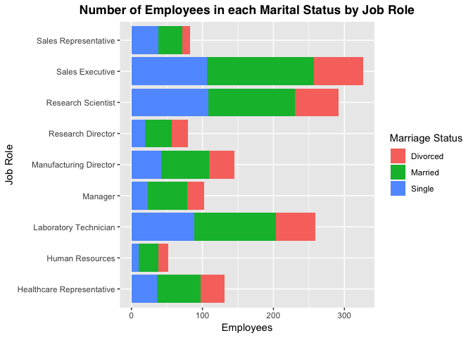

```r
emp_marital <- emp_data %>%
  group_by(JobRole) %>%
  summarise(Married = sum(MaritalStatus == "Married"),
            Single = sum(MaritalStatus == "Single"),
            Divorced = sum(MaritalStatus == "Divorced"))

# tidy to make grouped barplot
emp_marital_revised <- emp_marital %>%
  gather(Married, Single, Divorced,
         key = "Marriage Status", value = "Employees")

# plot
ggplot(emp_marital_revised, aes(JobRole, Employees, fill = `Marriage Status`)) +
  geom_bar(stat = "identity") +
  coord_flip() +
  ggtitle("Number of Employees in each Marital Status by Job Role") +
  xlab("Job Role") +
  labs(fill = "Marriage Status") +
  theme(plot.title = element_text(hjust = 0.5, face = "bold", family = "Helvetica"))
```

Immediately we can see Sales Execs, Research Scientists, and Lab Technicians comprise the majority of single, married, and divorced workers.

Do jobs that require more frequent travel also feature a higher number of divorced employees? Note that causality cannot be inferred here; in other words, we don’t know if they’re divorced for work-related reasons or not. We’re just seeking to establish correlation.

```r
emp_data %>%
  group_by(BusinessTravel) %>%
  summarise(Divorced = sum(MaritalStatus == "Divorced")) %>%
  arrange(desc(Divorced)) %>%
  kable(align = rep('c',2)) %>%
  kable_styling(bootstrap_options = "striped", full_width = F)
```

| BusinessTravel | Divorced |
| --- | --- |
| Travel_Rarely | 220 |
| Travel_Frequently | 63 |
| Non-Travel | 44 |

Those who travel frequently fall in the middle in terms of divorce numbers, but again we cannot make causal inferences.

Now we’ll like to see which job roles hold the highest average worker employment length

```r
emp_data %>%
  group_by(JobRole) %>%
  summarise(`Avg Yrs at Company` = round(mean(YearsAtCompany),2)) %>%
  arrange(desc(`Avg Yrs at Company`)) %>%
  kable(align = rep('c',2)) %>%
  kable_styling(bootstrap_options = "striped", full_width = F)
```

| JobRole | Avg Yrs at Company |
| --- | --- |
| Manager | 14.43 |
| Research Director | 10.94 |
| Healthcare Representative | 8.37 |
| Manufacturing Director | 7.60 |
| Sales Executive | 7.50 |
| Human Resources | 5.33 |
| Research Scientist | 5.11 |
| Laboratory Technician | 5.02 |
| Sales Representative | 2.92 |

Not surprisingly, Managers have worked longer at their current company and sales reps the least.

For each job role, do males or females tend to have longer commutes? Our initial guess is that distance doesn’t significantly differ. Let’s see:

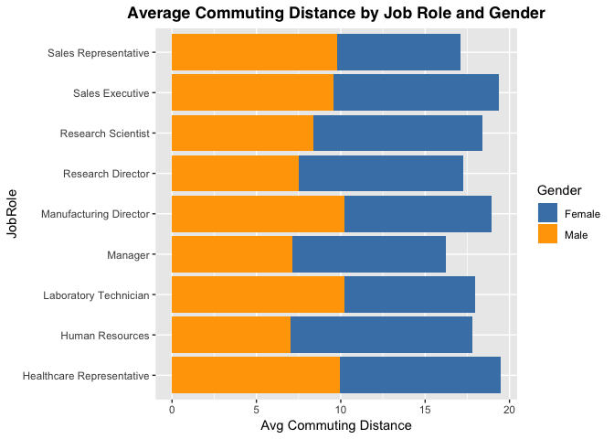

```r
emp_data %>%
  group_by(JobRole, Gender) %>%
  summarise(`Avg Commute Distance` = mean(DistanceFromHome)) %>%
  ggplot(aes(JobRole, `Avg Commute Distance`, fill = Gender)) +
  geom_bar(stat = "identity") +
  coord_flip() +
  ggtitle("Average Commuting Distance by Job Role and Gender") +
  ylab("Avg Commuting Distance") +
  theme(plot.title = element_text(hjust = 0.5, face = "bold", family = "Helvetica"))+
  scale_fill_manual(values = c("steel blue", "orange"))
```

Average commuting distance seems gender-invariant for the most part.

We’d also like to know which job roles include a higher travel burden.

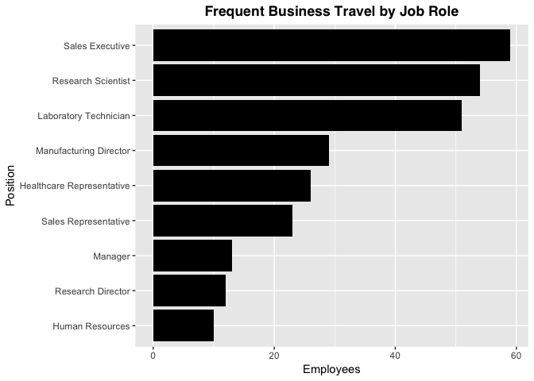

```r
emp_data %>%
  filter(BusinessTravel == "Travel_Frequently") %>%
  group_by(JobRole) %>%
  summarise(Employees = n()) %>%
  ggplot(aes(reorder(JobRole, Employees), Employees)) +
  geom_bar(stat = "identity", fill = "black") +
  coord_flip() +
  ggtitle("Frequent Business Travel by Job Role") +
  xlab("Position") +
  theme(plot.title = element_text(hjust = 0.5, face = "bold", family = "Helvetica")) +
  theme(legend.position = "none")
```

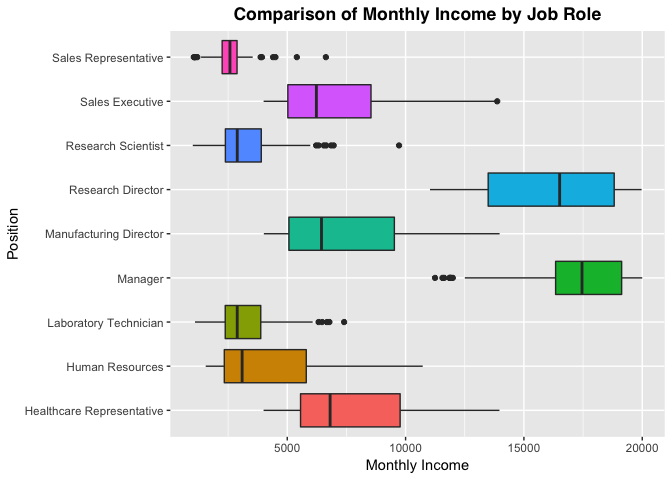

```r
ggplot(emp_data, aes(JobRole, MonthlyIncome, fill = JobRole)) +
  geom_boxplot() +
  coord_flip() +
  theme(legend.position = "none") +
  ggtitle("Comparison of Monthly Income by Job Role") +
  ylab("Monthly Income") +
  xlab("Position") +
  theme(plot.title = element_text(hjust = 0.5, face = "bold", family = "Helvetica"))
```

Interestingly, these two pairs respectively:

- Research Director + Manager
- Sales Executive + Manufacturing Director

both have virtually identical average monthly incomes and distributions, that is the range in monthly income for both pairs are approximately the same. The first pair are noticeably left-skewed while the second pair is right skewed.

Now, we’d like to examine features and trends relating to attrition. First, how does job involvement correlate to attrition for each job role?

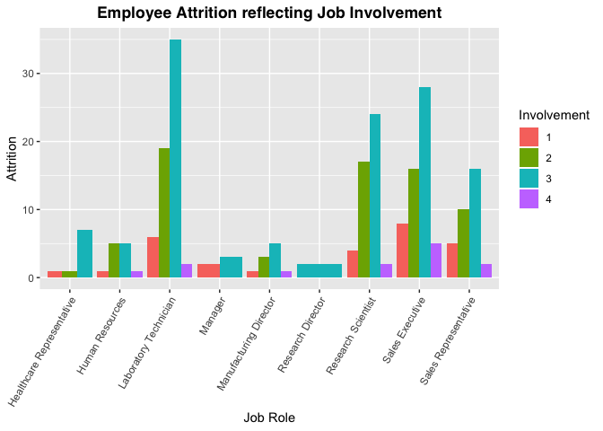

```r
# get a data frame summarizing attrition numbers by job involvement for each job role
emp_data$JobInvolvement %<>% as.character()
emp_data %>%
  filter(Attrition == "Yes") %>%
  group_by(JobRole, JobInvolvement) %>%
  summarise(Total = n()) %>%
  as.data.frame() %>%
  ggplot(aes(JobRole, Total, fill = JobInvolvement)) +
  geom_bar(stat = "identity", position = "dodge") +
  theme(axis.text.x = element_text(angle = 60, hjust = 1)) +
  ggtitle("Employee Attrition reflecting Job Involvement") +
  theme(plot.title = element_text(hjust = 0.5, face = "bold", family = "Helvetica")) +
  xlab("Job Role") + ylab("Attrition") + labs(fill = "Involvement")
```

It seems like those on the extremes (Involvement of 1 or 4), attrition is least. But for those with involvement falling somewhere in the middle (2 and 3), attrition is highest. It also shows that Healthcare reps, HR, Managers, Manufacturing Directors and Research Directors are the roles with fewest attrition.